# Power Analysis for Structural Equation Models: semPower 2 Manual

##### Detect whether the lag-1 autoregressive or moving average parameters differ across groups

To perform a power analysis to detect whether the lag-1 autoregressive or lag-1 moving average parameters differ across groups, use `nullEffect = 'autoregA = autoreg'` and `nullEffect = 'mvAvgA = mvAvgA'`, respectively.

The general syntax is similar as in the previous examples, with the only difference that the parameters targeted by the null hypothesis need to be provided in a list structure giving the relevant parameters separately for each group. If no list is provided for a particular parameter, these take identical values in all groups (but are freely estimated in each group by default). The measurement model must be identical across groups, so always provide the measurement model for a single group only (do not use a list structure).

For instance, the following defines a two-group model involving 5 measurement occasions (`nWaves = 5`), where $X$ is measured by three indicators at each measurement, with all loadings equal to .5. The measurement model is identical for both groups. Also identical across groups are the noise variances of 1 at each measurement, and equal moving average effects of .3 (`mvAvgLag1 = c(.3, .3, .3, .3)`). Whereas the moving average parameters are freely estimated in each group, the variances are restricted to equality across groups in both the H0 and the H1 model by using `groupEqual = c('var')`. However, different lag-1 autoregressive effects are defined for each group by using a list structure for the `autoregLag1` argument: In the first group, all autoregressive effects are .5, whereas in the second group, all autoregressive effects are .3. In both groups, the variance, autoregressive, and moving average parameters are constant across waves (`waveEqual = c('var', 'autoreg', 'mvAvg')`). Metric invariance constraints are applied across all waves and groups (by omitting the `invariance` argument, which defaults to `TRUE`). Then, the required sample size (`type = 'a-priori'`) is requested to detect that the autoregressive effect differs across groups (`nullEffect = 'autoregA = autoregB'`). Furthermore, in multiple group models the `N` argument also needs to be provided as a list, which in case of an a priori power analysis gives the group weights. `N = list(1, 1)` requests equally sized groups. If using `N = list(2, 1)` instead, the first group would be twice as large as the second group. If a post hoc or compromise power analysis is requested, `N` is a list providing the number of observations for each group.

```r
powerARMA <- semPower.powerARMA(
  # define type of power analysis
  type = 'a-priori', alpha = .05, power = .80, N = list(1, 1),
  # define hypothesis
  nWaves = 5,
  autoregLag1 = list(
    c(.5, .5, .5, .5),  # group 1: x1->x2, x2->x3, x3->x4, x4->x5
    c(.3, .3, .3, .3)   # group 2: x1->x2, x2->x3, x3->x4, x4->x5
  ),
  mvAvgLag1 = c(.3, .3, .3, .3),    # n1->x2, n2->x3, n3->x4, n4->x5
  variances = c(1, 1, 1, 1, 1),     # n1, n2, n3, n4, n5
  waveEqual = c('var', 'autoreg', 'mvAvg'),
  groupEqual = c('var'),
  nullEffect = 'autoregA = autoRegB',
  # define measurement model
  nIndicator = rep(3, 5), loadM = .5
)
```

If there are more than two groups, the autoregressive effects are held equal across all groups by default. If the constraints should only be placed in specific groups, `nullWhichGroups` is used to identify the groups to which the equality restrictions apply. For instance, `nullWhichGroups = c(1, 3)` defines that the autoregressive effects should only be restricted to equality across the first and the third group.

Performing a power analysis to detect that the moving average parameters differ across groups proceeds analogously. For instance, the following assumes wave-constant (`waveEqual = c('var', 'autoreg')`) autoregressive effects and variances, both of which take the same values groups. The variances, but not the autogressive effects, are also restricted to be equal across groups. Further, the moving average parameters are defined to differ across both waves and groups. In the first groups, the moving average parameters are .5, .5, .4, and .3, whereas in the second group these are .5, .2, .4, .3. As there are now several moving average parameters, `nullWhich = 2` defines that the second parameter (of .5 vs .2) is targeted by the hypothesis of group-equality (`nullEffect = 'mvAvgA = mvAvgB'`).

```r
powerARMA <- semPower.powerARMA(
  # define type of power analysis
  type = 'a-priori', alpha = .05, power = .80, N = list(1, 1),
  # define hypothesis
  nWaves = 5,
  autoregLag1 = c(.5, .5, .5, .5),
  mvAvgLag1 = list(
    c(.5, .5, .4, .3),  # group 1: n1->x2, n2->x3, n3->x4, n4->x5
    c(.5, .2, .4, .3)   # group 2: n1->x2, n2->x3, n3->x4, n4->x5
  ),
  variances = c(1, 1, 1, 1, 1),     # n1, n2, n3, n4, n5
  waveEqual = c('var', 'autoreg'),
  groupEqual = c('var'),
  nullEffect = 'mvAvgA = mvAvgB',
  nullWhich = 2,
  # define measurement model
  nIndicator = rep(3, 5), loadM = .5
)
```

##### Detect whether the variances or means differ across groups

To perform a power analysis to detect whether the variances of the noise factors (= the residual variances of $X$) differ across groups, use `nullEffect = 'varA = varB'`. To detect whether the means of $X$ differ across groups, use `nullEffect = 'meanA = meanB'`.

The general syntax is highly similar as in the previous examples. For instance, the following defines autoregressive and moving average parameters that are identical across waves and across groups, but defines the all variances in the first group equal 1, whereas all variances in the second group are .6. The variances, autoregressive effects, and moving average parameters are constant across measurements in both groups (`waveEqual = c('var', 'mvAvg', 'autoreg')`). Then, the required sample size to detect that the variances differ across groups is requested (`nullEffect = 'varA = varB'`).

```r
powerARMA <- semPower.powerARMA(
  # define type of power analysis
  type = 'a-priori', alpha = .05, power = .80, N = list(1, 1),
  # define hypothesis
  nWaves = 5,
  autoregLag1 = c(.5, .5, .5, .5),  # x1->x2, x2->x3, x3->x4, x4->x5
  mvAvgLag1 = c(.3, .3, .3, .3),    # n1->x2, n2->x3, n3->x4, n4->x5
  variances = list(
    c(1, 1, 1, 1, 1),         # n1, n2, n3, n4, n5
    c(.6, .6, .6, .6, .6)     # n1, n2, n3, n4, n5
  ),
  waveEqual = c('var', 'mvAvg', 'autoreg'),
  nullEffect = 'varA = varB',
  # define measurement model
  nIndicator = rep(3, 5), loadM = .5
)
```

The test for the inequality of the latent means of $X$ proceeds analogously. For instance, the following defines variances, autoregressive effects, and moving average parameters that are identical across waves and across groups, but defines all means in the first group to equal 0, whereas the conditional means (i.e., those of $X_2$ - $X_5$) in the second group are .5. In addition, the loadings and indicator intercepts are equal across both waves and groups, because the `invariance` argument (which defaults to `TRUE`) is omitted. Then, the required sample to detect that the means differ across groups is requested (`nullEffect = 'meanA = meanB'`).

```r
powerARMA <- semPower.powerARMA(
  # define type of power analysis
  type = 'a-priori', alpha = .05, power = .80, N = list(1, 1),
  # define hypothesis
  nWaves = 5,
  autoregLag1 = c(.5, .5, .5, .5),  # x1->x2, x2->x3, x3->x4, x4->x5
  mvAvgLag1 = c(.3, .3, .3, .3),    # n1->x2, n2->x3, n3->x4, n4->x5
  variances = c(1, 1, 1, 1, 1),     # n1, n2, n3, n4, n5
  means = list(
    c(0, 0, 0, 0, 0),         # n1, n2, n3, n4, n5
    c(0, .5, .5, .5, .5)     # n1, n2, n3, n4, n5
  ),
  waveEqual = c('var', 'mvAvg', 'autoreg', 'mean'),
  nullEffect = 'meanA = meanB',
  # define measurement model
  nIndicator = rep(3, 5), loadM = .5
)
```

## 4.12 CLPM models

`semPower.powerCLPM` is used to perform power analyses for hypothesis arising in cross-lagged panel models (CLPM). In a standard CLPM implemented here, two variables $X$ and $Y$ are repeatedly assessed at two (or more) different time points (waves) yielding autoregressive effects (stabilities; `X1 -> X2` and `Y1 -> Y2`), synchronous effects (`X1 <-> Y1` and `X2 <-> Y2`), and cross-lagged effects (`X1 -> Y2` and `Y1 -> X2`). `semPower.powerCLPM`provides interfaces to perform power analyses concerning the following hypotheses:

- whether the autoregressive effects of $X$ (`X1 -> X2`, `nullEffect = autoregX = 0`) or $Y$ (`Y1 -> Y2`, `autoregY = 0`) differ from zero.
- whether the cross-lagged effect of $X$ on $Y$ (`X -> Y`, `crossedX`) or the cross-lagged effect of $Y$ on $X$ (`Y -> X`, `crossedY`) differs from zero.
- whether the autoregressive effects of $X$ and $Y$ are equal (`autoregX = autoregY`).
- whether the cross-lagged effect of $X$ on $Y$ and the cross-lagged effect of $Y$ on $X$ are equal (`crossedX = crossedY`).
- whether the autoregressive effect of $X$ (`autoregX`) or the autoregressive effect of $Y$ (`autoregY`) are equal across waves.
- whether the cross-lagged effect of $X$ on $Y$ (`crossedX`) or the cross-lagged effect of $Y$ on $X$ (`crossedY`) are equal across waves.
- whether the (residual-)correlations between $X$ and $Y$ are equal across waves (`corXY`).
- whether the autoregressive effects of $X$ (`autoregXA = autoregXB`) or $Y$ (`autoregXA = autoregXB`) differ across groups.
- whether the cross-lagged effect of $X$ on $Y$ (`crossedXA = crossedXB`) or the cross-lagged effect of $Y$ on $X$ (`crossedYA = crossedYB`) differs across groups.

`semPower.powerCLPM` only addresses hypotheses arising in a CLPM structure. `semPower` provides other convenience functions for hypothesis arising in random intercept cross-lagged panel models and in generic path models. For hypotheses regarding global model fit, a model-free power analysis should be performed.

`semPower.powerCLPM` expects the following arguments:

- `nWaves`: The number of waves, must be at $\geq$ 2.
- `autoregEffects`: Vector of the autoregressive effects of $X$ and $Y$ (constant across waves), or a list of vectors of autoregressive effects for $X$ and $Y$ from wave to wave.
- `crossedEffects`: Vector of cross-lagged effects of $X$ on $Y$ (`X -> Y`) and of $Y$ on $X$ (`Y -> X`) (both constant across waves), or a list of vectors of cross-lagged effects for each wave.
- `rXY`: vector of (residual-)correlations between $X$ and $Y$ for each wave or `NULL` for no (residual-)correlations.
- `waveEqual`: Parameters that are assumed to be equal across waves in both the H0 and the H1 model. Valid are `'autoregX'` and `'autoregY'` for autoregressive effects, `'crossedX'` and `'crossedY'` for cross-lagged effects, `'corXY'` for residual correlations, or `NULL` for none.
- `nullEffect`: Defines the hypothesis of interest. Valid are the same arguments as in `waveEqual` and additionally `'autoregX = 0'`, `'autoregY = 0'`, `'crossedX = 0'`, `'crossedY = 0'` to constrain the $X$ or $Y$ autoregressive effects or the crossed effects to zero, `'autoregX = autoregY'` and `'crossedX = crossedY'` to constrain them to be equal for $X$ and $Y$, and `'autoregXA = autoregXB'`, `'autoregYA = autoregYB'`, `'crossedXA = crossedXB'`, `'crossedYA = crossedYB'` to constrain them to be equal across groups.
- `nullWhich`: Defines which parameter(s) is targeted by the hypothesis defined in `nullEffect` when there are > 2 waves.
- `nullWhichGroups`: For hypotheses involving cross-groups comparisons, vector indicating the groups for which equality constrains should be applied.
- `standardized`: Whether all parameters are standardized (`TRUE`, the default) or unstandardized (`FALSE`).
- `metricInvariance`: Whether metric invariance over waves is assumed (`TRUE`, the default) or not (`FALSE`). This generally affects power and may also affect the df, depending on the comparison model.
- `autocorResiduals`: Whether the residuals of the indicators of latent variables are autocorrelated over waves (`TRUE`, the default) or not (`FALSE`). This generally affects power and may also affect the df, depending on the comparison model.
- additional arguments specifying the type of power analysis.
- additional arguments defining the factor model, where the order of factors is ($X_1$, $Y_1$, $X_2$, $Y_2$, …, $X_{nWaves}$, $Y_{nWaves}$).

`semPower.powerCLPM` provides a list as result. Use the `summary` method to obtain formatted results. The list contains the following components:

- The results of the power analysis, which contain the same information as the corresponding model-free counterpart (see a-priori power analysis, post-hoc power analysis, and compromise hoc power analysis).
- `Sigma` and `mu`: Variance-covariance matrix and means in the population.
- `SigmaHat` and `muHat`: Model-implied variance-covariance matrix and means.
- `modelH0` and `modelH1`: `lavaan` model strings defining the H0 and the H1 model (only if `type = 'restricted'`).
- `simRes`: Detailed simulation results when a simulated power analysis (`simulatedPower = TRUE`) was performed.

##### Defining the CLPM structure

`semPower.powerCLPM` assumes that two variables $X$ and $Y$ are repeatedly assessed (a CLPM involving more than two variables can be more laboriously specified as a generic path model). The structure of a CLPM is defined by specifying `nWaves`, `autoregEffects`, `crossedEffects`, `rXY`, `standardized`, and `autocorResiduals`.

`nWaves` defines the number of measurements of $X$ and $Y$ and must be two or larger. Setting `nWaves = 2` implies the following regression equations:
$$\hat{X_2} = \beta_{X_2,X_1} \cdot X_1 + \beta_{X_2, Y_1} \cdot Y_1 \\
\hat{Y_2} = \beta_{Y_2,X_1} \cdot X_1 + \beta_{Y_2, Y_1} \cdot Y_1$$
So that $\beta_{X_2,X_1}$ is the autoregressive effect (the stability) of $X$ (`X1 -> X2`), $\beta_{Y_2, Y_1}$ is the autoregressive effect of $Y$ (`Y1 -> Y2`), $\beta_{X_2, Y_1}$ is the cross-lagged effect of $Y$ on $X$ (`Y1 -> X2`), and $\beta_{Y_2, X_1}$ is the cross-lagged effect of $X$ on $Y$ (`X1 -> Y2`). The correlation between $X_1$ and $Y_1$ (`X1 <-> Y1`) as well as the residual correlation between $X_2$ and $Y_2$ (`X2 <-> Y2`; the synchronous effects) are defined in `rXY`, which defaults to `NULL`, implying zero correlations. If setting `rXY = c(.3, .5)` the correlation between $X_1$ and $Y_1$ is .3, and the residual correlation between $X_2$ and $Y_2$ is .5.

When `nWaves = 3`, the system becomes
$$\hat{X_2} = \beta_{X_2,X_1} \cdot X_1 + \beta_{X_2, Y_1} \cdot Y_1 \\
\hat{Y_2} = \beta_{Y_2,X_1} \cdot X_1 + \beta_{Y_2, Y_1} \cdot Y_1 \\
\hat{X_3} = \beta_{X_3,X_2} \cdot X_2 + \beta_{X_3, Y_2} \cdot Y_2 \\
\hat{Y_3} = \beta_{Y_3,X_2} \cdot X_2 + \beta_{Y_3, Y_2} \cdot Y_2$$
so that there are now two autoregressive effects and two cross-lagged effects each for both $X$ and $Y$. Note that there are no lag-2 effects, meaning that neither $X_3$ nor $Y_3$ are predicted by $X_1$ and $Y_1$. This assumption cannot be relaxed in `semPower.powerCLPM`. Consider power analyses for generic path models when you need lag-2 effects.

The population values for the autoregressive effects, the cross-lagged effects, and the (residual-)correlations are defined in `autoregEffects`, `crossedEffects`, and `rXY`, respectively. When these effects are assumed to be constant across waves (as must be the case when there are two waves), `autoregEffects` and `crossedEffects` are vectors of size 2, giving the effects of $X$ and $Y$. For instance, `autoregEffects = c(.7, .6)` defines the autoregressive effect(s) of $X$ to be equal to .7, and those of $Y$ to be equal to .6. Similarly, `crossedEffects = c(.1, .2)` defines the cross-lagged effect of $X$ on $Y$ (`X -> Y`) to be .1, and the cross-lagged effect of $Y$ on $X$ (`Y -> X`) to be .20. Non-zero (residual) correlations always need to refer to each wave, so in case of two waves, `rXY` is a vector comprising two entries, the first giving the correlation between $X_1$ and $Y_1$, the second the residual correlation between $X_2$ and $Y_2$.

When there are more than two waves and wave-dependent autoregressive or cross-lagged effects are assumed, a list of vectors is supplied. For instance, in the case of three waves, `autoregEffects = list(c(.8, .7), c(.6, .5))` defines an autoregressive effect of .8 for `X1 -> X2` and of .6 for `X2 -> X3`, and an autoregressive effect of .7 for `Y1 -> Y2` and of .5 for `Y2 -> Y3`. When additionally specifying `crossedEffects = list(c(.1, .2), c(.3, .4))`, the system becomes:

$$\hat{X_2} = .8 \cdot X_1 + .2 \cdot Y_1 \\
\hat{Y_2} = .1 \cdot X_1 + .7 \cdot Y_1 \\
\hat{X_3} = .6 \cdot X_2 + .4 \cdot Y_2 \\
\hat{Y_3} = .3 \cdot X_2 + .5 \cdot Y_2$$
By default, all defined parameters in `autoregEffects`, `crossedEffects`, and `corXY` are treated as completely standardized parameters (`standardized = TRUE`). In this case `semPower` defines the residual variances in $\Psi$ such that all variances are 1. When `standardized` is set to `FALSE`, all diagonal elements of $\Psi$ are equal to 1, in turn leading to unstandardized parameters.

All of the above holds regardless of whether $X$ and $Y$ are latent factors or observed variables. To define the measurement model for $X$ and $Y$, and thereby also whether these are latent factors or observed variables, arguments defining the factor model are used assuming the order ($X_1$, $Y_1$, $X_2$, $Y_2$, …, $X_{nWaves}$, $Y_{nWaves}$). For instance, when there are two waves (`nWaves = 2`), the following shows three equivalent ways to define three indicators for $X$ and four indicators for $Y$ at both waves, where the loadings of each indicator on $X$ are equal to .50 and the loadings on $Y$ are equal to .60:

```r
# using Lambda
Lambda <- matrix(c(
  #  X1   Y1   X2   Y2
  c(0.5, 0.0, 0.0, 0.0),
  c(0.5, 0.0, 0.0, 0.0),
  c(0.5, 0.0, 0.0, 0.0),
  c(0.0, 0.6, 0.0, 0.0),
  c(0.0, 0.6, 0.0, 0.0),
  c(0.0, 0.6, 0.0, 0.0),
  c(0.0, 0.6, 0.0, 0.0),
  c(0.0, 0.0, 0.5, 0.0),
  c(0.0, 0.0, 0.5, 0.0),
  c(0.0, 0.0, 0.5, 0.0),
  c(0.0, 0.0, 0.0, 0.6),
  c(0.0, 0.0, 0.0, 0.6),
  c(0.0, 0.0, 0.0, 0.6),
  c(0.0, 0.0, 0.0, 0.6)
), ncol = 4, byrow = TRUE)
# using loadings
loadings <- list(
  c(.5, .5, .5),       # X1
  c(.6, .6, .6, .6),   # Y1
  c(.5, .5, .5),       # X2
  c(.6, .6, .6, .6)    # Y2
)
# using nIndicator and loadM
nIndicator = c(3, 4, 3, 4)    # X1, Y1, X2, Y2
loadM = c(.5, .6, .5, .6)     # X1, Y1, X2, Y2
```

Generally, when homogeneous loadings are assumed, `nIndicator` and `loadM` are probably the way to go, whereas the simplest way to specify heterogeneous loadings is offered by the `loadings` argument. When $X$ and $Y$ shall be observed variables (rather than latent factors), dummy factors with a single indicator loading by 1 are defined, which is most easily done by setting `Lambda = diag(p)`, where `p` is replaced by $2 \cdot nWaves$, so in case of two waves this becomes `Lambda = diag(4)`. For more details, see the chapter on the definition of the factor model.

Beyond the structure of the CLPM and particular values for the population parameters, `semPower.powerCLPM` also requires to define certain defaults that apply to both analysis models, i.e., to both the H0 model reflecting the hypothesis of interest and to the H1 comparison model. First, by default, the analyses models impose no equality constraints on the autoregressive effects, cross-lagged effects, and residual correlations over waves, i.e., the respective parameters (such as $\beta_{X_2,X_1}$ and $\beta_{X_3,X_2}$) are freely estimated for each wave. The `waveEqual` argument can be set to change this behavior. For instance, when setting `waveEqual = c('autoregX', 'autoregY')` both the autoregressive effect of $X$ and $Y$ are held equal over waves. When setting `waveEqual = c('autoregX', 'autoregY', 'crossedX', 'crossedY')`, both the autoregressive and the cross-lagged effects are constrained to equality over waves, so in this example the system becomes:

$$\hat{X_2} = \beta_{X,X} \cdot X_1 + \beta_{X, Y} \cdot Y_1 \\
\hat{Y_2} = \beta_{Y,X} \cdot X_1 + \beta_{Y, Y} \cdot Y_1 \\
\hat{X_3} = \beta_{X,X} \cdot X_2 + \beta_{X, Y} \cdot Y_2 \\
\hat{Y_3} = \beta_{Y,X} \cdot X_2 + \beta_{Y, Y} \cdot Y_2$$

To assume that the residual correlations between $X_2$ and $Y_2$ as well as between $X_3$ and $Y_3$ shall be equal, add `'corXY'` to `waveEqual`. Although the constraints defined in `waveEqual` apply to both the H0 and the H1 model, this will nevertheless affect statistical power.

Second, when $X$ and/or $Y$ are latent factors, the analyses models impose metric invariance constraints (equal loadings) over waves for the measurement model by default (`metricInvariance = TRUE`) and also assume that the residuals of the indicators are autocorrelated across waves (`autocorResiduals = TRUE`). Both can be set to `FALSE` to disable invariance constraints over waves and to disable estimation of autocorrelated residuals. However, it is generally recommended to interpret a CLPM structure only when invariance is met. In addition, the presence of invariance constraints as well as the presence of autocorrelated residuals also affects power for hypotheses concerning the CLPM parameters. Note that when `metricInvariance = TRUE`, the measurement model should be defined in a way that the invariance constraints are actually met by specifying identical loadings over waves for both $X$ and $Y$.

##### Detect whether a cross-lagged effect differs from zero

To perform a power analysis to detect whether the cross-lagged effect of either $X$ (`X -> Y`) or $Y$ (`Y -> X`) differs from zero, use `nullEffect = 'crossedX = 0'` or `nullEffect = 'crossedY = 0'`.

For instance, the following sets up a CLPM with two waves (`nWaves = 2`) and requests the required sample size (`type = 'a-priori'`) to detect that a cross-lagged effect of $X$ of at least .10 (`crossedEffects = c(.10, .15)`) differs from zero (`nullEffect = 'crossedX = 0'`) on alpha = .05 (`alpha = .05`) with a power of 80% (`power = .80`). The cross-lagged effect of $Y$ is .15, the autoregressive effects of $X$ and $Y$ are .6 and .7 (`autoregEffects = c(.6, .7)`), respectively, and the synchronous (residual-)correlations at the first and second wave are .3 and .1 (`rXY = c(.3, .1)`), respectively. $X$ is a latent factor measured by 5 indicators loading by .5 each (at both waves) and $Y$ is measured by 3 indicators loading by .6 each (at both waves; `nIndicator = c(5, 3, 5, 3)` and `loadM = c(.5, .6, .5, .6)`). See the section on defining the CLPM structure for details.

```r
powerCLPM <- semPower.powerCLPM(
                                # define type of power analysis
                                type = 'a-priori', alpha = .05, power = .80,
                                # define hypothesis
                                nullEffect = 'crossedX = 0',
                                nWaves = 2,
                                autoregEffects = c(.60, .70),
                                crossedEffects = c(.10, .15),
                                rXY = c(.3, .1),
                                # define measurement model
                                nIndicator = c(5, 3, 5, 3),
                                loadM = c(.5, .6, .5, .6)
                                )
summary(powerCLPM)
```

The results of the power analysis are printed by calling the `summary` method on `powerCLPM`, which, in this example, provides the same information as a model-free a-priori power analysis counterpart.

If a post hoc power analysis is desired, the arguments related to the power analysis need to be adapted accordingly:

```r
powerCLPM <- semPower.powerCLPM(
                                # define type of power analysis
                                type = 'post-hoc', alpha = .05, N = 500,
                                # define hypothesis
                                nullEffect = 'crossedX = 0',
                                nWaves = 2,
                                autoregEffects = c(.60, .70),
                                crossedEffects = c(.10, .15),
                                rXY = c(.3, .1),
                                # define measurement model
                                nIndicator = c(5, 3, 5, 3),
                                loadM = c(.5, .6, .5, .6)
                                )
```

Now, `summary(powerCLPM)` provides the same information as a model-free post-hoc power analysis counterpart. A compromise power analysis (`type = 'compromise'`) is performed analogously.

If the model does not include any factor, but is based on observed variables, the only change refers to the definition of the measurement model. Below, `Lambda = diag(4)` defines four dummy factors with a single indicator loading by 1, so these become observed variables:

```r
powerCLPM <- semPower.powerCLPM(
                                # define type of power analysis
                                type = 'a-priori', alpha = .05, power = .80,
                                # define hypothesis
                                nullEffect = 'crossedX = 0',
                                nWaves = 2,
                                autoregEffects = c(.60, .70),
                                crossedEffects = c(.10, .15),
                                rXY = c(.3, .1),
                                # define measurement model
                                Lambda = diag(4)
                                )
```

If the model comprises more than two waves and the autoregressive effects, cross-lagged effects, and/or synchronous residual correlations are considered stable across waves, the `waveEqual` can be used to define both the H0 and the H1 models to implement equality restrictions on these parameters. For instance, the following sets up a CLPM with three waves (`nWaves = 3`). Only a single value is provided for both $X$ and $Y$ concerning the autoregressive effects (`autoregEffects = c(.60, .70)`) and cross-lagged effects (`crossedEffects = c(.10, .15)`), so these are constant across waves. Similarly, `rXY = c(.3, .1, .1)` defines the residual correlations between $X$ and $Y$ at waves 2 and 3 to be equal to .10. The arguments provided to `waveEqual` ensure that the analyses models implement equality restrictions over waves on the autoregressive effects, crossed-lag effects, and the residual correlations at wave 2 and 3. Both the H0 model and the comparison model implement these restrictions and merely differ with respect to the hypothesized effect (the absence of the cross-lagged effect of $X$, `nullEffect = 'crossedX = 0'`).

```r
powerCLPM <- semPower.powerCLPM(
                                # define type of power analysis
                                type = 'a-priori', alpha = .05, power = .80,
                                # define hypothesis
                                nullEffect = 'crossedX = 0',
                                nWaves = 3,
                                autoregEffects = c(.60, .70),
                                crossedEffects = c(.10, .15),
                                rXY = c(.3, .1, .1),
                                waveEqual = c('autoregX', 'autoregY', 'crossedX', 'crossedY', 'corXY'),
                                # define measurement model
                                Lambda = diag(6)
                                )
```

In all examples above, a power analysis was performed by comparing the implied H0 model against a less restrictive H1 model (by omitting the `comparison` argument which defaults to `'restricted'`). If one rather wants to compare the H0 model against the saturated model, use `comparison = 'saturated'`. See the chapter on the definition of the comparison model for a detailed discussion.

##### Detect whether an autoregressive effect differs from zero

To perform a power analysis to detect whether the autoregressive effect of either $X$ or $Y$ differs from zero, use `nullEffect = 'autoregX = 0'` or `nullEffect = 'autoregY = 0'`.

For instance, the following sets up a CLPM with two waves (`nWaves = 2`) and requests the required sample size (`type = 'a-priori'`) to detect that an autoregressive effect of $X$ of at least .50 (`autoregEffects = c(.50, .80)`) differs from zero (`nullEffect = 'autoregX = 0'`) on alpha = .05 (`alpha = .05`) with a power of 80% (`power = .80`). The autoregressive effect of $Y$ is .80, the cross-lagged effects of $X$ and $Y$ are .10 and .05 (`crossedEffects = c(.10, .05)`), respectively, and the synchronous (residual-)correlations at the first and second wave are .2 and .3 (`rXY = c(.2, .3)`), respectively. $X$ is a latent factor measured by 3 indicators loading by .5 each (at both waves) and $Y$ is measured by 3 indicators loading by .7 each (at both waves; `nIndicator = c(3, 3, 3, 3)` and `loadM = c(.5, .7, .5, .7)`). See the section on defining the CLPM structure for details.

```r
powerCLPM <- semPower.powerCLPM(
                                # define type of power analysis
                                type = 'a-priori', alpha = .05, power = .80,
                                # define hypothesis
                                nullEffect = 'autoregX = 0',
                                nWaves = 2,
                                autoregEffects = c(.50, .80),
                                crossedEffects = c(.10, .05),
                                rXY = c(.2, .3),
                                # define measurement model
                                nIndicator = c(3, 3, 3, 3),
                                loadM = c(.5, .7, .5, .7)
                                )
```

##### Detect whether the cross-lagged effects of $X$ and $Y$ differ

To perform a power analysis to detect whether the cross-lagged effect of $X$ (`X -> Y`) differs from the cross-lagged effect of $Y$ (`Y -> X`) , use `nullEffect = 'crossedX = crossedY'`.

```r
powerCLPM <- semPower.powerCLPM(
                                # define type of power analysis
                                type = 'a-priori', alpha = .05, power = .80,
                                # define hypothesis
                                nullEffect = 'crossedX = crossedY',
                                nullWhich = 1,
                                nWaves = 3,
                                autoregEffects = c(.60, .70),
                                crossedEffects = list(
                                  c(.05, .15),     # X1 -> Y2; X2 -> Y3
                                  c(.15, .20)      # Y1 -> X2; Y2 -> X3
                                ),
                                rXY = c(.3, .1, .1),
                                waveEqual = c('autoregX', 'autoregY', 'corXY'),
                                # define measurement model
                                nIndicator = c(10, 8, 10, 8, 10, 8),
                                loadM = c(.7, .6, .7, .6, .7, .6)
                                )
```

##### Detect whether the autoregressive effects of $X$ and $Y$ differ

To perform a power analysis to detect whether the autoregressive effect of $X$ differs from the autoregressive effect of $Y$, use `nullEffect = 'autoregX = autoregY'`.

For instance, the following sets up a CLPM in the same way as in the previous section and requests the required sample size (`type = 'a-priori'`) to detect that the autoregressive effect of $X$ differs from the autoregressive effect of $Y$ (`nullEffect = 'autoregX = autoregY'`) on alpha = .05 (`alpha = .05`) with a power of 80% (`power = .80`). Because the autoregressive effects of both $X$ and $Y$ are constant across waves (`autoregEffects = c(.60, .70)`), which is also an assumption made in both the H0 and the H1 model (`waveEqual = c('autoregX', 'autoregY', 'corXY')`), there is in fact only one autoregressive effect each for $X$ and $Y$, so the `nullWhich` argument can be omitted.

```r
powerCLPM <- semPower.powerCLPM(
                                # define type of power analysis
                                type = 'a-priori', alpha = .05, power = .80,
                                # define hypothesis
                                nullEffect = 'autoregX = autoregY',
                                nWaves = 3,
                                autoregEffects = c(.60, .70),
                                crossedEffects = list(
                                  c(.05, .15),     # X1 -> Y2; X2 -> Y3
                                  c(.15, .20)      # Y1 -> X2; Y2 -> X3
                                ),
                                rXY = c(.3, .1, .1),
                                waveEqual = c('autoregX', 'autoregY', 'corXY'),
                                # define measurement model
                                nIndicator = c(10, 8, 10, 8, 10, 8),
                                loadM = c(.7, .6, .7, .6, .7, .6)
                                )
```

##### Detect whether the cross-lagged effects differ across waves

To perform a power analysis to detect whether the cross-lagged effects of either $X$ or $Y$ differ across waves, use `nullEffect = 'crossedX'` or `nullEffect = 'crossedY'`. This is only meaningful when there are at least 3 waves.

```r
powerCLPM <- semPower.powerCLPM(
                                # define type of power analysis
                                type = 'a-priori', alpha = .05, power = .80,
                                # define hypothesis
                                nullEffect = 'crossedX',
                                nWaves = 3,
                                autoregEffects = list(
                                  c(.60, .70),     # X1 -> X2; X2 -> X3
                                  c(.70, .70)      # Y1 -> Y2; Y2 -> Y3
                                ),
                                crossedEffects = list(
                                  c(.05, .15),     # X1 -> Y2; X2 -> Y3
                                  c(.15, .20)      # Y1 -> X2; Y2 -> X3
                                ),
                                rXY = c(.3, .1, .1),
                                waveEqual = c('corXY'),
                                # define measurement model
                                nIndicator = c(10, 8, 10, 8, 10, 8),
                                loadM = c(.7, .6, .7, .6, .7, .6)
                                )
```

##### Detect whether the autoregressive effects differ across waves

To perform a power analysis to detect whether the autoregressive effects of either $X$ or $Y$ differ across waves, use `nullEffect = 'autoregX'` or `nullEffect = 'autoregY'`. This is only meaningful when there are at least 3 waves.

For instance, the following sets up a CLPM in the same way as in the previous section and requests the required sample size (`type = 'a-priori'`) to detect that the autoregressive effect of $X$ differs across waves (`nullEffect = 'autoregX'`) on alpha = .05 (`alpha = .05`) with a power of 80% (`power = .80`). Note that the autoregressive effects of $Y$ do not change over waves, so in this example performing a power analysis with `nullEffect = 'autoregY'` would not be possible, as there is no difference to detect.

```r
powerCLPM <- semPower.powerCLPM(
                                # define type of power analysis
                                type = 'a-priori', alpha = .05, power = .80,
                                # define hypothesis
                                nullEffect = 'autoregX',
                                nWaves = 3,
                                autoregEffects = list(
                                  c(.60, .70),     # X1 -> X2; X2 -> X3
                                  c(.70, .70)      # Y1 -> Y2; Y2 -> Y3
                                ),
                                crossedEffects = list(
                                  c(.05, .15),     # X1 -> Y2; X2 -> Y3
                                  c(.15, .20)      # Y1 -> X2; Y2 -> X3
                                ),
                                rXY = c(.3, .1, .1),
                                waveEqual = c('corXY'),
                                # define measurement model
                                nIndicator = c(10, 8, 10, 8, 10, 8),
                                loadM = c(.7, .6, .7, .6, .7, .6)
                                )
```

##### Detect whether the residual correlations between $X$ and $Y$ differ across waves

To perform a power analysis to detect whether the residual correlations between $X$ and $Y$ differ across waves, use `nullEffect = 'corXY'`. This is only meaningful when there are at least 3 waves, because otherwise there is only a single residual correlation (namely the one at wave 2; the synchronous correlation at wave 1 is not residualized and therefore not subject of any equality constraint).

```r
powerCLPM <- semPower.powerCLPM(
                                # define type of power analysis
                                type = 'a-priori', alpha = .05, power = .80,
                                # define hypothesis
                                nullEffect = 'corXY',
                                nWaves = 3,
                                autoregEffects = list(
                                  c(.60, .70),     # X1 -> X2; X2 -> X3
                                  c(.70, .70)      # Y1 -> Y2; Y2 -> Y3
                                ),
                                crossedEffects = c(.05, .15),
                                rXY = c(.3, .2, .1),
                                waveEqual = c('crossedX', 'crossedY', 'autoregY'),
                                standardized = FALSE,
                                # define measurement model
                                nIndicator = c(10, 8, 10, 8, 10, 8),
                                loadM = c(.7, .6, .7, .6, .7, .6)
                                )
```

Whereas all previous examples were based on standardized effects (by omitting the `standardized` argument which defaults to `TRUE`), hypotheses referring to the residual correlations require `standardized` to be set to `FALSE`, because the equality restrictions are always applied on unstandardized parameters, which in case of the residual correlations generally differ from the standardized parameters.

##### Detect whether the cross-lagged effect of $X$ or $Y$ differs across groups

To perform a power analysis to detect whether the cross-lagged effect of $X$ or the one of $Y$ differs across groups, use `nullEffect = 'crossedXA = crossedXB'` or `nullEffect = 'crossedYA = crossedYB'`.

Since `semPower.powerCLPM` by default applies metric invariance constraints across both waves and groups (`metricInvariance = TRUE`), the measurement model is defined to be identical in both groups: $X$ is a latent factor measured by 5 indicators loading by .5 each (at all three waves) and $Y$ is measured by 3 indicators loading by .4 each (at all three waves; `nIndicator` and `loadM`). Furthermore, in multiple group models, the `N` argument also needs to be provided as a list, which in case of an a priori power analysis gives the group weights. `N = list(1, 1)` requests equally sized groups. If using `N = list(2, 1)` instead, the first group would be twice as large as the second group. If a post hoc or compromise power analysis is requested, `N` is a list providing the number of observations for each group.

```r
powerCLPM <- semPower.powerCLPM(
                                # define type of power analysis
                                type = 'a-priori', alpha = .05, power = .80, N = list(1, 1),
                                # define hypothesis
                                nullEffect = 'crossedXA = crossedXB',
                                nWaves = 3,
                                autoregEffects = list(
                                  # group 1
                                  list(c(.80, .80),   # X1 -> X2, X2 -> X3
                                       c(.70, .70)),  # Y1 -> Y2, Y2 -> Y3
                                  # group 2
                                  list(c(.60, .60),   # X1 -> X2, X2 -> X3
                                       c(.70, .70))   # Y1 -> Y2, Y2 -> Y3
                                ),
                                crossedEffects = list(
                                  # group 1
                                  list(c(.10, .10),   # X1 -> Y2, X2 -> Y3
                                       c(.05, .05)),  # Y1 -> X2, Y2 -> X3
                                  # group 2
                                  list(c(.20, .20),   # X1 -> Y2, X2 -> Y3
                                       c(.05, .05))   # Y1 -> X2, Y2 -> X3
                                ),
                                waveEqual = c('autoregX', 'autoregY', 'crossedX', 'crossedY'),
                                rXY = NULL,
                                # define measurement model
                                nIndicator = c(5, 3, 5, 3, 5, 3),
                                loadM = c(.5, .4, .5, .4, .5, .4)
                                )
```

```r
powerCLPM <- semPower.powerCLPM(
                                # define type of power analysis
                                type = 'a-priori', alpha = .05, power = .80, N = list(1, 1, 1),
                                # define hypothesis
                                nullEffect = 'crossedXA = crossedXB',
                                nullWhich = 1,
                                nullWhichGroups = c(1, 3),
                                nWaves = 3,
                                autoregEffects = c(.80, .70),  # (X->Y, Y->X) in all groups and all waves
                                crossedEffects = list(
                                  # group 1
                                  list(c(.05, .20),   # X1 -> Y2, X2 -> Y3
                                       c(.00, .05)),  # Y1 -> X2, Y2 -> X3
                                  # group 2
                                  list(c(.10, .10),   # X1 -> Y2, X2 -> Y3
                                       c(.15, .15)),  # Y1 -> X2, Y2 -> X3
                                  # group 3
                                  list(c(.20, .20),   # X1 -> Y2, X2 -> Y3
                                       c(.05, .10))   # Y1 -> X2, Y2 -> X3
                                ),
                                waveEqual = c('autoregX', 'autoregY'),
                                rXY = c(.3, .3, .3),  # for all groups
                                # define measurement model
                                nIndicator = c(5, 3, 5, 3, 5, 3),
                                loadM = c(.5, .4, .5, .4, .5, .4)
                                )
```

##### Detect whether the autoregressive effect of $X$ or $Y$ differs across groups

To perform a power analysis to detect whether the autoregressive effect of $X$ or $Y$ differs across groups, use `nullEffect = 'autoregXA = autoregXB'` or `nullEffect = 'autoregYA = autoregYB'`.

For instance, the following defines a CLPM similar to the example in the previous section, with three alterations: First, no list is provided as argument to `crossedEffects`, so the crossed-effects of both $X$ and $Y$ are assumed to be both constant across waves and equal across groups. Second, both the H0 and the H1 model merely assume the crossed effects to be constant across waves (`waveEqual = c('crossedX', 'crossedY')`). Third, the autoregressive effect of $X$ differs both across waves and across groups (`autoregEffects`). Specifically, whereas the autoregressive effect of $X$ from wave 1 to wave 2 is .80 in both groups, the autoregressive effect of $X$ from wave 2 to wave 3 is .80 in the first group, but .60 in the second group. Because there are now multiple autoregressive effects for $X$, `nullWhich = 2` is used to identify the effect on which the cross-group constraint should be applied.

```r
powerCLPM <- semPower.powerCLPM(
                                # define type of power analysis
                                type = 'a-priori', alpha = .05, power = .80, N = list(1, 1),
                                # define hypothesis
                                nullEffect = 'autoregXA = autoregXB',
                                nullWhich = 2,
                                nWaves = 3,
                                autoregEffects = list(
                                  # group 1
                                  list(c(.80, .80),   # X1 -> X2, X2 -> X3
                                       c(.70, .70)),  # Y1 -> Y2, Y2 -> Y3
                                  # group 2
                                  list(c(.80, .60),   # X1 -> X2, X2 -> X3
                                       c(.70, .70))   # Y1 -> Y2, Y2 -> Y3
                                ),
                                crossedEffects = c(.10, .05), # (X->Y, Y->X) in all groups and all waves
                                waveEqual = c('crossedX', 'crossedY'),
                                rXY = NULL,
                                # define measurement model
                                nIndicator = c(5, 3, 5, 3, 5, 3),
                                loadM = c(.5, .4, .5, .4, .5, .4)
                                )
```

## 4.13 RI-CLPM models

`semPower.powerRICLPM` is used to perform power analyses for hypotheses arising in random intercept cross-lagged panel models (RI-CLPM). Given that RI-CLPMs extend traditional CLPMs, the following only covers the differences between `semPower.powerRICLPM` and `semPower.powerCLPM`. Consult the chapter on the traditional CLPM for a detailed description of the relevant parameters and arguments shared by both methods.

The arguments expected by `semPower.powerRICLPM` are identical to those expected by `semPower.powerCLPM`, with the following exceptions:

- `nWaves` must be $\geq$ 3.
- `rBXBY` defines the correlation between the random intercept factors (or `NULL` for no correlation).
- `nullEffect` also accepts `'corBXBY = 0'` to constrain the correlation between the random intercept factors to zero and `'corBXBYA = corBXBYB'` to constrain the correlation between the random intercept factors to be equal across groups.
- Standardized parameters (`standardized`) are not available.

##### Detect whether the correlation between the random intercept factors differs from zero

To perform a power analysis to detect whether the correlation between the random intercept factors differs from zero, use `nullEffect = 'corBXBY = 0'`.

For instance, the following sets up a RI-CLPM with three waves (`nWaves = 3`) and requests the required sample size (`type = 'a-priori'`) to detect that the correlation between the random intercept factors (of .30; `rBXBY= .30`) differs from zero (`nullEffect = 'corBXBY = 0'`) on alpha = .05 (`alpha = .05`) with a power of 80% (`power = .80`). The autoregressive effects of $X$ and $Y$ are .5 and .4 (`autoregEffects = c(.5, .4)`), respectively. The cross-lagged effects of $X$ is .2, the cross-lagged effect of $Y$ is .1 (`crossedEffects = c(.2, .1)`). Both the autoregressive and the cross-lagged effects of both $X$ and $Y$ are equal across waves (but freely estimated in each wave, as `waveEqual` is not set). All synchronous correlations (`rXY = NULL`) are zero. For more details on the arguments, see the chapter on traditional CLPMs.

```r
powerRICLPM <- semPower.powerRICLPM(
                                    # define type of power analysis
                                    type = 'a-priori', alpha = .05, power = .80,
                                    # define hypothesis
                                    nullEffect = 'corBXBY = 0',
                                    nWaves = 3,
                                    autoregEffects = c(.5, .4),   # (X, Y)
                                    crossedEffects = c(.2, .1),   # (X, Y)
                                    rXY = NULL,                   # diagonal
                                    rBXBY = .30,
                                    # define measurement model
                                    nIndicator = rep(3, 6),
                                    loadM = rep(c(.5, .6), 3)
                                    )
```

##### Detect whether the correlations between the random intercept factors differ across groups

When performing a multigroup analysis, `autoregEffects` and/or `crossedEffects` must be provided in a list structure, where each component specifies the values for a particular group. When aiming to detect a group difference in the correlation between the intercept factors, `rBXBY` must be a list as well.

```r
powerRICLPM <- semPower.powerRICLPM(
                                    # define type of power analysis
                                    type = 'a-priori', alpha = .05, power = .80, N = list(1, 1),
                                    # define hypothesis
                                    nullEffect = 'crossedXA = crossedXB',
                                    nullWhich = 2,
                                    nWaves = 3,
                                    autoregEffects = c(.5, .4),   # constant across waves and groups
                                    crossedEffects = list(
                                    # group 1
                                    list(
                                      c(.25, .10),    # X1 -> Y2, X2 -> Y3
                                      c(.05, .15)     # Y1 -> X2, Y2 -> X3
                                      ),
                                    # group 2
                                    list(
                                       c(.15, .05),   # X1 -> Y2, X2 -> Y3
                                       c(.01, .10)    # Y1 -> X2, Y2 -> X3
                                       )
                                    ),
                                    rXY = NULL,                   # diagonal
                                    rBXBY = list(.3, .6),         # (group1, group2)
                                    # define measurement model (same for all groups)
                                    nIndicator = rep(3, 6),
                                    loadM = rep(c(.5, .6), 3)
                                    )
```

## 4.14 Latent growth curve models

`semPower.powerLGCM` is used to perform power analyses for hypotheses arising in latent growth curve models (LGCM), where one variable $X$ is repeatedly assessed at different occasions (waves). A latent intercept and a linear (and optionally a quadratic) latent slope factor representing the random effects capturing individual differences in change over time is assumed, and there might also be a time-invariant covariate. `semPower.powerLGCM` provides interfaces to perform power analyses concerning the following hypotheses:

- whether the mean of the intercept (`nullEffect = 'iMean = 0'`), linear slope (`'sMean = 0'`), or quadratic slope (`'s2Mean = 0'`) factor, respectively, is zero.
- whether the variance of the intercept (`'iVar = 0'`), linear slope (`'sVar = 0'`), or quadratic slope (`'s2Var = 0'`) factor, respectively, is zero.
- whether the covariance between the intercept and linear slope (`'isCov = 0'`), between the intercept and the quadratic slope (`'is2Cov = 0'`), or between the linear and the quadratic slope (`'ss2Cov = 0'`) is zero.
- whether the slope for an exogenous time-invariant covariate in the prediction of the intercept factor (`'betaIT = 0'`; $I = \beta_{it} \cdot TIC$), the linear slope factor (`'betaST = 0'`; $S = \beta_{st} \cdot TIC$), or the quadratic slope factor (`'betaS2T = 0'`; $S^2 = \beta_{s^2t} \cdot TIC$), respectively, is zero.
- whether the slope for the intercept factor (`'betaTI = 0'`), the linear slope factor (`'betaTS = 0'`), or the quadratic slope factor (`'betaTS2 = 0'`), respectively, in the prediction of an endogenous time-invariant covariate is zero (i.e., $TIC = \beta_{ti} \cdot I + \beta_{ts} \cdot S + \beta_{ts^2} \cdot S^2$).
- whether the means of the intercept (`'iMeanA = iMeanB'`), linear slope (`'sMeanA = sMeanB'`), or quadratic slope (`'s2MeanA = s2MeanB'`) factor, respectively, are equal across groups.
- whether the variances of the intercept (`'iVarA = iVarB'`), linear slope (`'sVarA = sVarB'`), or quadratic slope (`'s2VarA = s2VarB'`) factor, respectively, are equal across groups.
- whether the covariances between the intercept and linear slope (`'isCovA = isCovA'`), between the intercept and the quadratic slope (`'is2CovA = is2CovA'`), or between the linear and the quadratic slope (`'ss2CovA = ss2CovA'`) factor are equal across groups.
- whether the slopes for the time-invariant covariate in the prediction of the intercept (`'betaITA = betaITB'`), the linear slope (`'betaSTA = betaSTB'`), or the quadratic slope (`'betaS2TA = betaS2TB'`) factor, respectively, are equal across groups.
- whether the slope the intercept (`'betaTIA = betaTIB'`), the linear slope (`'betaTSA = betaTSB'`), or the quadratic slope (`'betaTS2A = betaTS2B'`) factor, respectively, in the prediction of the time-invariant covariate are equal across groups.

For hypotheses regarding longitudinal invariance, see semPower.powerLI().

Note that power analyses concerning the hypotheses `iVar = 0`, `sVar = 0`, and `s2Var = 0` are only approximate, because the H0 model involves a parameter constraint on the boundary of the parameter space (a variance of zero), so that the correct limiting distribution is a mixture of non-central $\chi^2$ distributions (see Stoel et al., 2006). In effect, power is (slightly) underestimated.

`semPower.powerLGCM` expects the following arguments:

- `nWaves`: The number of waves (measurement occasions), must be $\geq$ 3 for linear and $\geq$ 4 for quadratic trends.
- `quadratic`: Whether to include a quadratic slope factor in addition to a linear slope factor. Defaults to `FALSE` for no quadratic slope factor.
- `means`: Vector of means for the intercept factor, linear slope factor, and quadratic slope factor (if present), e.g. `c(.5, .25, .1)` for a mean of the intercept factor of .5, of the linear slope factor of .25, and of the quadratic slope factor of .1.
- `variances`: Vector of variances for the intercept factor, linear slope factor, and quadratic slope (if present), e.g. `c(1, .5, .2)` for a variance of the intercept factor of 1, of the linear slope factor of .5, and of the quadratic slope factor of .2. Can be omitted if a matrix is provided to the `covariances` argument.
- `covariances`: Either the variance-covariance matrix between the intercept and the linear slope (and the quadratic slope factor if present), or a single number giving the covariance between the intercept and linear slope factor, or `NULL` for orthogonal factors. If a matrix is provided and the `variances` argument is also set, the diagonal is replaced by the values defined in `variances`.
- `timeCodes`: Vector of length `nWaves` defining the loadings on the slope factor. If omitted, the time codes default to $(0, 1, ..., (nWaves - 1))$.
- `ticExogSlopes`: Vector defining the slopes for an exogenous time-invariant covariate (TIC) in the prediction of the intercept and slope factors (and the quadratic slope factor, if present), e.g. `c(.5, .4, .3)` for $I = .5 \cdot TIC$, $S = .4 \cdot TIC$, and $S^2 = .3 \cdot TIC$. Can be omitted for no exogenous covariate.
- `ticEndogSlopes`: Vector defining the slopes for the intercept and slope factors (and the quadratic slope factor, if present) in the prediction of an endogenous time-invariant covariate (TIC), e.g. `c(.5, .4, .3)` for $TIC = .5 \cdot I + .4 \cdot S + .3 \cdot S^2$. Can be omitted for no endogenous covariate.
- `groupEqual`: Parameters that are restricted to equality across groups in both the H0 and the H1 model, when `nullEffect` implies a multiple group model. Valid are `'imean'`, `'smean'`, `'s2mean'` to restrict the means of the intercept, linear slope, and quadratic slope factors, and `'ivar'`, `'svar'`, `'s2var'` for their variances, and `'iscov'`, `'is2cov'`, `'ss2cov'` for the covariances between intercept and slope, intercept and quadratic slope, and linear and quadratic slope, respectively.
- `nullEffect`: Defines the hypothesis of interest. See the previous paragraph for valid arguments.
- `nullWhichGroups`: For hypotheses involving cross-groups comparisons, vector indicating the groups for which equality constrains should be applied. By default, the relevant parameter(s) are restricted to equality across all groups.
- `autocorResiduals`: Whether the residuals of the indicators of $X$ are autocorrelated over waves (`TRUE`, the default) or not (`FALSE`).
- additional arguments specifying the type of power analysis.
- additional arguments defining the factor model, where the order of factors is ($X_1$, $X_2$, …, $X_{nWaves}$, $TIC_{exog}$, $TIC_{endog}$), where $TIC_{endog}$ takes the place of $TIC_{exog}$ if there is no exogenous TIC.

`semPower.powerLGCM` provides a list as result. Use the `summary` method to obtain formatted results. The list contains the following components:

- The results of the power analysis, which contain the same information as the corresponding model-free counterpart (see a-priori power analysis, post-hoc power analysis, and compromise hoc power analysis).
- `Sigma` and `mu`: Variance-covariance matrix and means in the population.
- `SigmaHat` and `muHat`: Model-implied variance-covariance matrix and means.
- `modelH0` and `modelH1`: `lavaan` model strings defining the H0 and the H1 model (only if `type = 'restricted'`).
- `simRes`: Detailed simulation results when a simulated power analysis (`simulatedPower = TRUE`) was performed.

##### Detect that the mean of the intercept, linear or quadratic slope factor differs from zero

To perform a power analysis to detect whether the mean of the intercept factor, the slope factor, or the quadratic slope factor (if present) differs from zero, use `nullEffect = 'iMean'`, `nullEffect = 'sMean'`, and `nullEffect = 'iMean2'`, respectively.

```r
powerLGCM <- semPower.powerLGCM(
  # define type of power analysis
  type = 'a-priori', alpha = .05, power = .80,
  # define hypothesis
  nWaves = 3,
  means = c(.5, .2),     # i, s
  variances = c(1, .5),  # i, s
  covariances = .25,
  nullEffect = 'sMean = 0',
  # define measurement model
  nIndicator = rep(3, 3), loadM = .5
)
summary(powerLGCM)
```

The results of the power analysis are printed by calling the `summary` method on `powerLGCM`, which in this example provides the same information as a model-free a-priori power analysis counterpart.

If a post hoc power analysis is desired, the arguments related to the power analysis need to be adapted accordingly:

```r
powerLGCM <- semPower.powerLGCM(
  # define type of power analysis
  type = 'post-hoc', alpha = .05, N = 300,
  # define hypothesis
  nWaves = 3,
  means = c(.5, .2),     # i, s
  variances = c(1, .5),  # i, s
  covariances = .25,
  nullEffect = 'sMean = 0',
  # define measurement model
  nIndicator = rep(3, 3), loadM = .5
)
```

Now, `summary(powerLGCM)` provides the same information as a model-free post-hoc power analysis counterpart. A compromise power analysis (`type = 'compromise'`) is performed analogously.

In the examples above, a power analysis was performed by comparing the implied H0 model against a less restrictive H1 model (by omitting the `comparison` argument which defaults to `'restricted'`). If one rather wants to compare the H0 model against the saturated model, use `comparison = 'saturated'`. See the chapter on the definition of the comparison model for a detailed discussion.

Instead of defining the variances and the covariances separately, a variance-covariance matrix can also be provided to the `covariances` argument. For instance, the following is equivalent to the example above:

```r
powerLGCM <- semPower.powerLGCM(
  # define type of power analysis
  type = 'a-priori', alpha = .05, power = .80,
  # define hypothesis
  nWaves = 3,
  means = c(.5, .2),     # i, s
  covariances = matrix(c(
      # i, s
    c(1, .25),
    c(.25, .5)
    ), ncol = 2, byrow = TRUE),
  nullEffect = 'sMean = 0',
  # define measurement model
  nIndicator = rep(3, 3), loadM = .5
)
```

If the LGCM should be based on observed rather than latent indicator variables (yielding a first-order LGCM), the only change refers to the definition of the measurement model. Below, `Lambda = diag(3)` defines three dummy factors with a single indicator loading by 1, so these become observed variables:

```r
powerLGCM <- semPower.powerLGCM(
  # define type of power analysis
  type = 'a-priori', alpha = .05, power = .80,
  # define hypothesis
  nWaves = 3,
  means = c(.5, .2),     # i, s
  variances = c(1, .5),  # i, s
  covariances = .25,
  nullEffect = 'sMean = 0',
  # define measurement model
  Lambda = diag(3)
)
```

It is also possible to include a quadratic slope factor by adding `quadratic = TRUE`. For instance, the following defines a LGCM involving 4 measurements (`nWaves = 4`) and includes a quadratic slope factor (`quadratic = TRUE`) in addition to the intercept and the linear slope factor. `means` now gives the means for the intercept, linear, and quadratic slope factors, and `covariances` the associated variance-covariance matrix. Thus, the quadratic slope factor has a mean of .10, a variance of .10, and exhibits a covariance of .10 to the intercept factor and of .05 to the slope factor. Then, the required sample size to detect that the mean of the quadratic slope factor differs from zero (`nullEffect = 's2Mean = 0'`) is requested.

```r
powerLGCM <- semPower.powerLGCM(
  # define type of power analysis
  type = 'a-priori', alpha = .05, power = .80,
  # define hypothesis
  nWaves = 4,
  quadratic = TRUE,
  means = c(.5, .2, .1),     # i, s, s2
  covariances = matrix(c(
    # i,   s,   s2
    c(1, .25, .10),
    c(.25, .5, .05),
    c(.10, .05, .10)
  ), ncol = 3, byrow = TRUE),
  nullEffect = 's2Mean = 0',
  # define measurement model
  nIndicator = rep(3, 4), loadM = .5
)
```

##### Detect that the variance of the intercept, linear or quadratic slope factor differs from zero

Performing a power analysis concerning the hypothesis that the variance of the mean, the linear slope, or the quadratic slope factor is zero proceeds largely identically as described above, with the exception that `nullEffect` now refers to the variances. To detect that the variance of the intercept factor differs from zero, use `nullEffect = 'iVar'`, to detect that the variance of the slope factor differs from zero, use `nullEffect = 'sVar'`, and to detect that the variance of the quadratic slope factor differs from zero, use `nullEffect = 's2Var'`.

For instance, the following defines a LGCM involving 4 measurements (`nWaves = 4`) and includes a quadratic slope factor (`quadratic = TRUE`) in addition to the intercept and the linear slope factor. The variances of the intercept, linear slope, and quadratic slope factors are 1, .5, and .10 (the diagonal elements of the matrix provided to `covariances`). Then, the required sample size to detect that the variance of the intercept factor differs from zero (`nullEffect = 'iVar = 0'`) is requested.

```r
powerLGCM <- semPower.powerLGCM(
  # define type of power analysis
  type = 'a-priori', alpha = .05, power = .80,
  # define hypothesis
  nWaves = 4,
  quadratic = TRUE,
  means = c(.5, .2, .1),     # i, s, s2
  covariances = matrix(c(
    # i,   s,   s2
    c(1, .25, .10),
    c(.25, .5, .05),
    c(.10, .05, .10)
  ), ncol = 3, byrow = TRUE),
  nullEffect = 'iVar = 0',
  # define measurement model
  nIndicator = rep(3, 4), loadM = .5
)
```

##### Detect that a covariance between intercept, linear or quadratic slope factors differs from zero

Performing a power analysis concerning the hypothesis that a covariance between intercept, slope, and quadratic slope factor is zero again proceeds largely identically as described above, with the exception that `nullEffect` now refers to the covariances. To detect that the covariance between the intercept and the linear slope factor differs from zero, use `nullEffect = 'isCov'`, to detect that the covariance between the intercept and the quadratic slope factor differs from zero, use `nullEffect = 'is2Cov'`, and detect that the covariance between the linear and the quadratic slope factor differs from zero, use `nullEffect = 'ss2Cov'`,

For instance, the following defines a LGCM involving 4 measurements (`nWaves = 4`) and includes a quadratic slope factor (`quadratic = TRUE`) in addition to the intercept and the linear slope factor. The covariance between the intercept and the linear slope is .25, the covariance between the intercept and the quadratic slope is .10, and the covariance between the linear and the quadratic slope factors is .05 (the off-diagonal elements of the matrix provided to `covariances`). Then, the required sample size to detect that the covariance between the intercept and the linear slope factor differs from zero (`nullEffect = 'isCov = 0'`) is requested.

```r
powerLGCM <- semPower.powerLGCM(
  # define type of power analysis
  type = 'a-priori', alpha = .05, power = .80,
  # define hypothesis
  nWaves = 4,
  quadratic = TRUE,
  means = c(.5, .2, .1),     # i, s, s2
  covariances = matrix(c(
    # i,   s,   s2
    c(1, .25, .10),
    c(.25, .5, .05),
    c(.10, .05, .10)
  ), ncol = 3, byrow = TRUE),
  nullEffect = 'isCov = 0',
  # define measurement model
  nIndicator = rep(3, 4), loadM = .5
)
```

##### Detect that a slope of a time-invariant covariate differs from zero

To perform a power analysis to detect whether the slope of an exogenous time-invariant covariate (TIC) differs from zero, use `nullEffect = 'betaIT'` for the prediction of the intercept factor, `nullEffect = 'betaST'` for the prediction of the slope factor, and `nullEffect = 'betaS2T'` for the prediction of the quadratic slope factor. These types of hypotheses assume that an additional exogenous TIC is present, which is used to predict the intercept factor, the slope factor, and the quadratic slope factor, implying the following regression equations:
$$\hat{I} = \beta_{IT} \cdot TIC \\
\hat{S} = \beta_{ST} \cdot TIC \\
\hat{S^2} = \beta_{S^2T} \cdot TIC$$

For instance, the following defines a LGCM involving 3 waves along with an additional exogenous time-invariant covariate. The measurement model for the covariate also needs to be defined, which in the example is done via the `loadings` argument. An exogenous covariate is defined after the factors associated with the measurements of $X$, so in the present example factors 1 - 3 refer to the repeated assessments of the attribute under consideration, and the fourth factor is the covariate. Here, the covariate is measured by 4 indicators loading by .8, .6, .5, and .6. The slopes of the covariate in the prediction of the intercept and slope factors are defined in `ticExogSlopes`, so that the slope of the covariate in the prediction of the intercept factor is .1, and the slope in the prediction of the slope factor is .5 (`ticExogSlopes = c(.1, .5)`). Then, the required sample size is requested to detect that the slope of the covariate in the prediction of the slope factor differs from zero (`nullEffect = 'betaST = 0'`).

```r
powerLGCM <- semPower.powerLGCM(
  # define type of power analysis
  type = 'a-priori', alpha = .05, power = .80,
  # define hypothesis
  nWaves = 3,
  means = c(.5, .2),           # i, s
  variances = c(1, 1),         # i, s
  covariances = .3,
  ticExogSlopes = c(.1, .5),   # i, s
  nullEffect = 'betaST = 0',
  # define measurement model
  loadings = list(
    c(.5, .6, .7),       # x1
    c(.5, .6, .7),       # x2
    c(.5, .6, .7),       # x3
    c(.8, .6, .5, .6)    # tic
  )
)
```

##### Detect that a slope in the prediction of an time-invariant covariate differs from zero

To perform a power analysis to detect whether a slope in the prediction of an endogenous time-invariant covariate (TIC) differs from zero, use `nullEffect = 'betaTI'` for the slope of the intercept factor, `nullEffect = 'betaTS'` for the slope of the slope factor, and `nullEffect = 'betaTS2'` for the slope of the quadratic slope factor. These types of hypotheses assume that an additional endogenous TIC is present, which is predicted by the intercept factor, the slope factor, and the quadratic slope factor, implying the following regression equation:
$$\widehat{TIC} = \beta_{TI} \cdot I + \beta_{TS} \cdot S + \beta_{TS^2} \cdot S^2$$

For instance, the following defines a LGCM involving 3 waves along with an additional endogenous time-invariant covariate. The measurement model for the covariate also needs to be defined, which in the example is done via the `loadings` argument. An endogenous covariate is defined after the factors associated with the measurements of $X$, and - if also present - after an exogenous covariate, so in the present example factors 1 - 3 refer to the repeated assessments of the attribute under consideration, and the fourth factor is the covariate. Here, the covariate is measured by 4 indicators loading by .8, .6, .5, and .6. The slopes of intercept and the slope factors in the prediction of the covariate are defined in `ticEndogSlopes`, so that the slope of the intercept factor is .3, and the slope of the slope factor is .2 (`ticEndogSlopes = c(.3, .2)`). Then, the required sample size is requested to detect that the slope of the intercept factor in the prediction covariate differs from zero (`nullEffect = 'betaTI = 0'`).

```r
powerLGCM <- semPower.powerLGCM(
  # define type of power analysis
  type = 'a-priori', alpha = .05, power = .80,
  # define hypothesis
  nWaves = 3,
  means = c(.5, .2),           # i, s
  variances = c(1, 1),         # i, s
  covariances = .3,
  ticEndogSlopes = c(.3, .2),  # i, s
  nullEffect = 'betaTI = 0',
  # define measurement model
  loadings = list(
    c(.5, .6, .7),       # x1
    c(.5, .6, .7),       # x2
    c(.5, .6, .7),       # x3
    c(.8, .6, .5, .6)    # tic
  )
)
```

##### Detect whether the means or variances of the intercept and slope factors differ across groups

To perform a power analysis to detect whether the means of the intercept, slope, or quadratic slope factors differ across groups, use `nullEffect = 'iMeanA = iMeanB'`,`nullEffect = 'sMeanA = sMeanB'`, and `nullEffect = 's2MeanA = s2MeanB'`, respectively. To detect that the respective variances differ across groups, use `nullEffect = 'iVarA = iVarB'`,`nullEffect = 'sVarA = sVarB'`, and `nullEffect = 's2VarA = s2VarB'`, respectively.

The general syntax is similar as in the previous examples, with the only difference that the parameters targeted by the null hypothesis need to be provided in a list structure giving the relevant parameters separately for each group. If no list is provided for a particular parameter, these take identical values in all groups (but are freely estimated in each group by default).

For instance, the following defines a two-group model involving 3 measurement occasions (`nWaves = 3`), where $X$ is measured by three indicators at each measurement, with all loadings equal to .5. The measurement model is identical for both groups. Also identical in both groups (but freely estimated) are the variances of the intercept and slope factors, which are 1 (`variances = c(1, 1)`), as well as the intercept-slope covariance (`covariances = .3,`). However, different intercept and slope factor means for each group are defined by using a list structure for the `means` argument: In the first group, the means of the intercept and slope factors are .5 and .2, respectively, whereas in the second group, the means are 0 and .4. Loadings and indicator intercepts are always constrained to be equal across all waves and groups. Then, the required sample size is requested to detect that the means of the intercept factor differ across groups (`nullEffect = 'iMeanA = iMeanB'`). Furthermore, in multiple group models the `N` argument also needs to be provided as a list, which in case of an a priori power analysis gives the group weights. `N = list(1, 1)` requests equally sized groups. If using `N = list(2, 1)` instead, the first group would be twice as large as the second group. If a post hoc or compromise power analysis is requested, `N` is a list providing the number of observations for each group.

```r
powerLGCM <- semPower.powerLGCM(
  # define type of power analysis
  type = 'a-priori', alpha = .05, power = .80, N = list(1, 1),
  # define hypothesis
  nWaves = 3,
  means = list(
    c(.5, .2),          # group 1: i, s
    c(.0, .4)           # group 2: i, s
  ),
  variances = c(1, 1),         # i, s
  covariances = .3,
  nullEffect = 'iMeanA = iMeanB',
  # define measurement model
  nIndicator = rep(3, 3), loadM = rep(.5, 3)
)
```

If there are more than two groups, the autoregressive effects are held equal across all groups by default. If the constraints should only be placed in specific groups, `nullWhichGroups` is used to identify the groups to which the equality restrictions apply. For instance, `nullWhichGroups = c(1, 3)` defines that the means should only be restricted to equality across the first and the third group.

Performing a power analysis to detect that the variances of the intercept, slope, or quadratic slope factor differs across groups proceeds analogously. For instance, the following defines a two-group model with equal means for the intercept (of .5) and slope (of .2) factors in both groups (`means = c(.5, .2)`), but uses a list structure for the `variances` argument to define that the variance of the intercept is .5 in both groups, whereas the variance of the slope is 1 in the first, but .5 in the second group. Then, the required sample size is requested to detect that the variances of the slope factors differ across groups (`nullEffect = 'sVarA = sVarB'`).

```r
powerLGCM <- semPower.powerLGCM(
  # define type of power analysis
  type = 'a-priori', alpha = .05, power = .80, N = list(1, 1),
  # define hypothesis
  nWaves = 3,
  means = c(.5, .2),           # i, s
  variances = list(
    c(.5, 1),           # group 1: i, s
    c(.5, .5)           # group 2: i, s
  ),
  covariances = .3,
  nullEffect = 'sVarA = sVarB',
  # define measurement model
  nIndicator = rep(3, 3), loadM = rep(.5, 3)
)
```

##### Detect whether the intercept-slope covariances differ across groups

To perform a power analysis to detect group-differences in the covariances between intercept and slope factor, intercept and quadratic slope factor, and linear slope and quadratic slope factor, use `nullEffect = 'isCovA = isCovB'`,`nullEffect = 'is2CovA = is2CovB'`, and `nullEffect = 'ss2CovA = ss2CovB'`, respectively.

The procedure is largely identical as described in the previous section. For instance, the following defines a two-group model with equal means and variances for the intercept and slope factors in both groups, but uses `covariances = list(.3, 0)` to define that the intercept-slope covariance is .3 in the first group, but 0 in the second group. Moreover, the variances of both the intercept and the slope factor have identical values in both groups (`variances = c(1, 1)`) and are also restricted to be equal across groups in both the H0 and the H1 model by using `groupEqual = c('iVar', 'sVar')`. Then, the required sample size is requested to detect that the covariances differ across groups (`nullEffect = 'isCovA = isCovB'`).

```r
powerLGCM <- semPower.powerLGCM(
  # define type of power analysis
  type = 'a-priori', alpha = .05, power = .80, N = list(1, 1),
  # define hypothesis
  nWaves = 3,
  means = c(.5, .2),              # i, s
  variances = c(1, 1),            # i, s
  covariances = list(.3, 0),      # group1, group2
  groupEqual = c('iVar', 'sVar'),
  nullEffect = 'isCovA = isCovB',
  # define measurement model
  nIndicator = rep(3, 3), loadM = rep(.5, 3)
)
```

##### Detect whether slopes involving a time-invariant covariate differ across groups

To perform a power analysis to detect group-differences in the slope for an exogenous time-invariant covariate, use `nullEffect = 'betaITA = betaITB'` concerning the prediction of the intercept factor, `nullEffect = 'betaSTA = betaSTB'` concerning the prediction of the slope factor, and `nullEffect = 'betaS2TA = betaS2TB'` concerning the prediction of the quadratic slope factor.

For instance, the following defines a two-group model involving 3 measurement occasions (`nWaves = 3`). The measurement model is identical for both groups. Also identical across groups are the means, variances and covariances of the intercept and slope factors. Variances and covariances are also restricted to be equal across groups in both the H0 and the H1 model by using `groupEqual = c('iVar', 'sVar', 'isCov')`. However, different slopes for the covariate in the prediction of the intercept and the slope factors are defined by using a list structure for the `ticExogSlopes` argument: The slope in the prediction of the intercept factor is .5 in the first group, but .1 in the second group, and the slope in the prediction of the slope factor is .1 in the first group, but .2 in the second group. Then, the required sample size is requested to detect that the slopes for the covariate in the prediction of the intercept factors differ across groups (`nullEffect = 'betaITA = betaITB'`).

```r
powerLGCM <- semPower.powerLGCM(
  # define type of power analysis
  type = 'a-priori', alpha = .05, power = .80, N = list(1, 1),
  # define hypothesis
  nWaves = 3,
  means = c(.5, .2),     # i, s
  variances = c(1, 1),   # i, s
  covariances = .3,
  groupEqual = c('iVar', 'sVar', 'isCov'),
  ticExogSlopes = list(
    c(.5, .1),           # group 1: i, s
    c(.1, .2)            # group 2: i, s
  ),
  nullEffect = 'betaITA = betaITB',
  # define measurement model
  loadings = list(
    c(.5, .6, .7),       # x1
    c(.5, .6, .7),       # x2
    c(.5, .6, .7),       # x3
    c(.8, .6, .5, .6)    # tic
  )
)
```

When the slopes of the growth factors in the prediction of an endogenous time-invariant covariate are of concern, use `nullEffect = 'betaTIA = betaTIB'` to detect that the slope of the intercept factor differs across groups, `nullEffect = 'betaTSA = betaTSB'` for the slope of the linear slope factor, and `nullEffect = 'betaTS2A = betaTS2B'` for the slope of the quadratic slope factor.

For instance, the following defines group-specific slopes for the intercept and the slope factor in the prediction of the covariate by using a list structure for the `ticEndogSlopes` argument: The slopes for the intercept in the prediction of the covariate factor is .3 in the first group, but .1 in the second group, and the slope of the slope factor is .2 in the first group, but .5 in the second group. Then, the required sample size is requested to detect that the slopes for the slope factor in the prediction of the covariate differ across groups (`nullEffect = 'betaTSA = betaTSB'`).

```r
powerLGCM <- semPower.powerLGCM(
  # define type of power analysis
  type = 'a-priori', alpha = .05, power = .80, N = list(1, 1),
  # define hypothesis
  nWaves = 3,
  means = c(.5, .2),     # i, s
  variances = c(1, 1),   # i, s
  covariances = .3,
  groupEqual = c('iVar', 'sVar', 'isCov'),
  ticEndogSlopes = list(
    c(.3, .2),           # group 1: i, s
    c(.1, .5)            # group 2: i, s
  ),
  nullEffect = 'betaTSA = betaTSB',
  # define measurement model
  loadings = list(
    c(.5, .6, .7),       # x1
    c(.5, .6, .7),       # x2
    c(.5, .6, .7),       # x3
    c(.8, .6, .5, .6)    # tic
  )
)
```

## 4.15 Generic model-based power analysis

All of the functions described above implement a high-level approach towards performing model-based power analysis to facilitate the definition of the relevant models and hypotheses. At times, one might want to perform model-based power analyses that are not immediately covered by one of these functions. Therefore, `semPower` also provides a more generic way to perform a model-based power analysis via the `semPower.powerLav` function that requires the direct specification of the H0 and H1 `lavaan` model strings as well as either the population covariance matrix (and means) or the population model.

Consider the situation that one is interested in determining whether the observed responses on 8 items reflect two separate (but correlated) factors or can be described by assuming just a single factor. A suitable model to test this hypothesis would specify two factors and constrain their correlation to 1. When this constrained model fits the data, a single factor is sufficient. Otherwise, two factors are required.

Suppose that a correlation between two factors of $r > .9$ is considered as implying that these are practically equivalent, so these could be collapsed into a single factor. The misfit associated with a model assuming a correlation of 1 when, in reality, the true correlation is $\leq$ .9 is supposed to define the magnitude of effect. This scenario is not covered by the `semPower.powerCFA` function, so some manual work to achieve this is required. Three steps are required to perform a power analysis in this scenario:

- Define the population model that describes the true situation in the population or provide the population covariance matrix.
- Define an (incorrect) analysis model that reflects the null hypothesis of interest.
- Optionally, define a (correct) analysis model that reflects the alternative hypothesis.

##### Define the true affairs in the population

One option to define the true affairs in the population is to use a `lavaan` model string specifying the values for each single (non-zero) parameter. Thus, recurring to the example above, one needs to define each loading, each residual variance, the variance of the factors as well as their covariance. Suppose the standardized loadings vary between .4 and .8, and that - in the population - the two factors correlate by .9.

```r
# define (true) population model
modelPop <- '
# define relations between factors and items in terms of loadings
f1 =~ .7*x1 + .7*x2 + .5*x3 + .5*x4
f2 =~ .8*x5 + .6*x6 + .6*x7 + .4*x8
# define the unique variances of the items to be equal to 1-loading^2,
# so that the loadings above are in a standardized metric
x1 ~~ .51*x1
x2 ~~ .51*x2
x3 ~~ .75*x3
x4 ~~ .75*x4
x5 ~~ .36*x5
x6 ~~ .64*x6
x7 ~~ .64*x7
x8 ~~ .84*x8
# define the variances of f1 and f2 to be 1
f1 ~~ 1*f1
f2 ~~ 1*f2
# define covariance (=correlation, because factor variances are 1)
# between the factors to be .9
f1 ~~ 0.9*f2
'
```

Instead of defining a population model via a `lavaan` model string, it is also possible to provide the population covariance matrix directly. A useful utility function supporting this process is `semPower.genSigma`. For instance, the following returns the very same population covariance matrix (`generated$Sigma`) as implied by the `lavaan` model string defined above:

```r
generated <- semPower.genSigma(Phi = .90,
                               loadings = list(
                                 c(.7, .7, .5, .5),
                                 c(.8, .6, .6, .4)))
```

See `semPower.genSigma` for more information.

##### Define the H0 and the H1 models

Having defined the true affairs in the population, one now needs to define the (incorrect) analysis model reflecting the null hypothesis of interest. This model should make at least one restriction which is factually wrong and thereby defines the effect of interest. In the present case, the factually wrong restriction is that the two factors correlate to 1:

```r
# define (wrong) analysis model
modelH0 <- '
f1 =~ NA*x1 + x2 + x3 + x4
f2 =~ NA*x5 + x6 + x7 + x8
# define variances of f1 and f2 to be 1
f1 ~~ 1*f1
f2 ~~ 1*f2
# set correlation between the factors to 1
f1 ~~ 1*f2
'
```

Whereas the population model (or the population covariance matrix) and the H0 model are sufficient to perform a power analysis, one can also define an explicit H1 model which is to be compared against the H0 model. Below, the H1 model is defined in a way that it is correct, so this only affects the df for the power analysis.

```r
# define (correct) comparison model
modelH1 <- '
f1 =~ NA*x1 + x2 + x3 + x4
f2 =~ NA*x5 + x6 + x7 + x8
# define variances of f1 and f2 to be 1
f1 ~~ 1*f1
f2 ~~ 1*f2
# freely estimate the correlation between the factors to 1
f1 ~~ f2
'
```

When `semPower.genSigma` is used to obtain a population covariance matrix, a correct H1 model string is also returned (`generated$modelTrue`), so one might skip the explicit definition of the H1 model and just use the returned string. Indeed, using this approach, one might also modify the returned model string to reflect the actual hypothesis of interest. Instead of writing the complete H0 and H1 model strings as tediously done in full detail above, the very same may also be achieved through

```r
generated <- semPower.genSigma(Phi = .90,
                               loadings = list(
                                 c(.7, .7, .5, .5),
                                 c(.8, .6, .6, .4)))
modelH1 <- generated$modelTrue
# define modelH0 as function of modelH1 plus the
# additional constraint of interest
modelH0 <- paste(modelH1, 'f1 ~~ 1*f2', sep = '\n')
```

##### Perform a power analysis

Finally, all these information are plugged into `semPower.powerLav()`, in this example, requesting an a priori power analysis:

```r
# using the population model
ap <- semPower.powerLav(type = 'a-priori', alpha = .05, power = .80,
                        modelPop = modelPop, modelH0 = modelH0, modelH1 = modelH1)
# using the population covariance matrix
ap <- semPower.powerLav(type = 'a-priori', alpha = .05, power = .80,
                        Sigma = generated$Sigma, modelH0 = modelH0, modelH1 = modelH1)
summary(ap)
```

Beyond the results of the power analysis, the result returned by `semPower.powerLav` also contains a number of additional information, in particular, the generated population covariance matrix $\Sigma$ (`Sigma`) and the model-implied covariance matrix $\hat{\Sigma}$ (`SigmaHat`). If using `lavaan` to generate the population covariance matrix, it is a good idea to check whether the population model actually defined all parameters in line with the expectations. To verify, one can just fit the correct H1 model to the population covariance matrix which should yield a perfect fit and give the same parameter estimates used in the definition of the model string.

```r
library(lavaan)
summary(sem(modelH1, sample.cov = ap$Sigma,
            sample.nobs = 1000, sample.cov.rescale = FALSE),
        stand = TRUE, fit = TRUE)
```

Note that the `sample.nobs` are arbitrary and that `sample.cov.rescale = FALSE` must be added to prevent `lavaan` from modifying the provided covariance matrix.

# 5 Power Plots

Power plots show the implied power as a function of some other variable. `semPower` provides two different types of power plots. One can either plot the achieved power to detect a certain effect over a range of different sample sizes (`semPower.powerPlot` and `semPower.powerPlot.byN`). Alternatively, one can plot the achieved power with a given $N$ to detect a range of different effect size magnitudes (`semPower.powerPlot.byEffect`).

## 5.1 Power by N for a given effect

The result of any model-based power analysis can be plugged into `semPower.powerPlot` to obtain a plot showing the achieved power to detect the effect of interest over a range of sample sizes. For instance, the following first performs a power analysis concerning the correlation between two CFA factors (see the corresponding chapter for details), and then plugs the result into the `semPower.powerPlot` function.

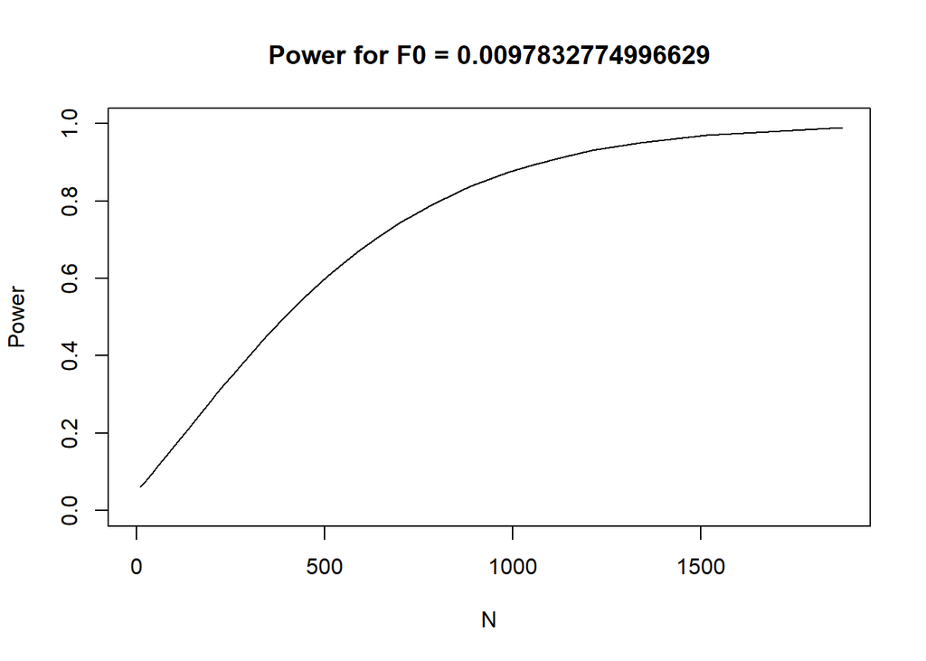

Figure 5.1: Power as function of the N to detect the effect as defined in powerCFA

```r
# perform a power analysis
powerCFA <- semPower.powerCFA(
  type = 'post-hoc', alpha = .05, N = 300,
  Phi = .15, nIndicator = c(5, 4), loadM = c(.5, .6))
# show plot
semPower.powerPlot(powerCFA)
```

This shows that the power to detect the specified effect is high when N > 1,000, whereas power is small when N < 250.

A more generic way is provided by the function `semPower.powerPlot.byN`, which creates a plot showing the achieved power to detect a given effect on a given alpha error over a range of sample sizes. However, because it is difficult to specify diagnostic sample sizes for a given effect, the `semPower.powerPlot.byN` instead asks to provide the desired power range. For example, suppose one is interested in how the power to detect an effect corresponding to RMSEA = .05 changes as a function of the number of observations N. The interest lies on the power ranging from .05 to .99 (note that the power cannot be smaller than alpha). This is achieved by setting the arguments `power.min = .05` and `power.max = .99`. In addition, as in any a priori power analysis, the type and magnitude of effect, the df, and the alpha error need to be defined: `effect = .05`, `effect.measure = 'RMSEA'`,`alpha = .05`, `df = 100`.

```r
semPower.powerPlot.byN(effect = .05, effect.measure = 'RMSEA',
                       alpha = .05, df = 100, power.min = .05, power.max = .99)
```

## 5.2 Power by the magnitude of effect for a given N

The function `semPower.powerPlot.byEffect` creates a plot showing the achieved power at a given sample size over a range of effect sizes. For example, suppose one is interested in how the power at N = 500 changes as function of effect size magnitude, corresponding to an RMSEA ranging from .001 to .10. This is achieved by setting the arguments `effect.measure = 'RMSEA'`, `effect.min = .001` and `effect.max = .10`. In addition, as in any post hoc power analysis, the sample size, the df, and the alpha error need to be defined: `N = 500`, `df = 100`, `alpha = .05`.

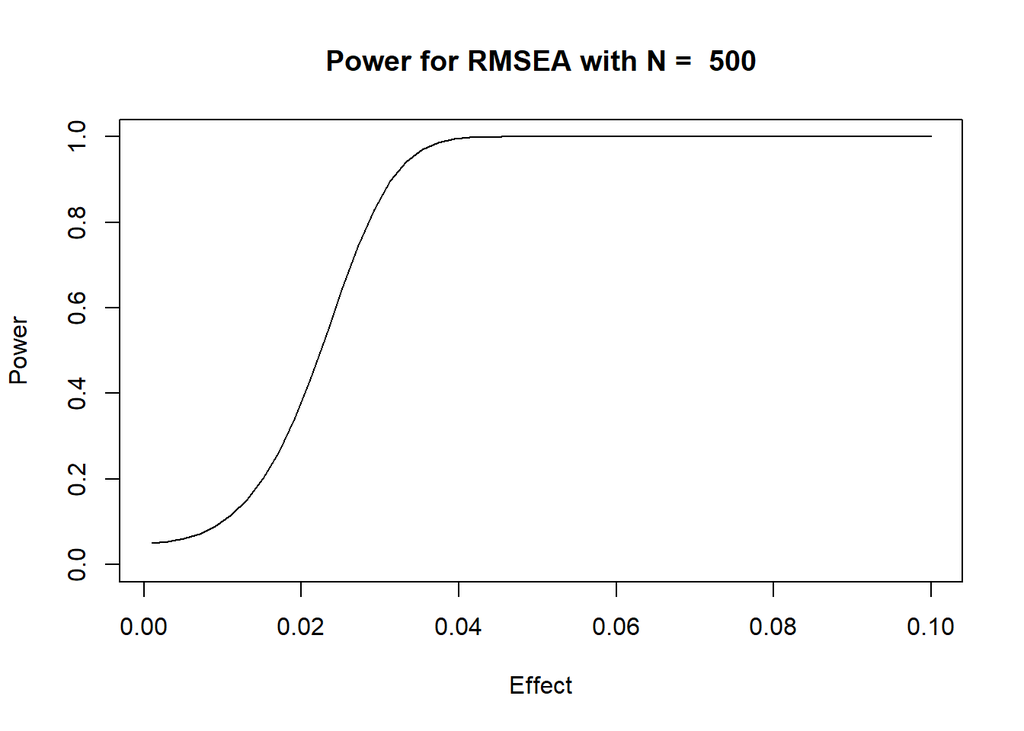

Figure 5.2: Power as function of the RMSEA with N = 500.

```r
semPower.powerPlot.byEffect(effect.measure = 'RMSEA', alpha = .05, N = 500,
                            df = 100, effect.min = .001, effect.max = .10)
```

# 6 Further topics

## 6.1 Obtain the model degrees of freedom

Knowledge of the degrees of freedom (df) is required to perform a power analysis. When power refers to the comparison of two explicitly specified, nested models, the resulting df are just the difference between the df of the two models (or equivalently, the number of free parameters removed by the more restrictive model). When power is requested for the comparison of a hypothesized model to the saturated model, the model df are given by

$$df = p\cdot(p+1)/2 - q$$

where $p$ is the number of observed variables and $q$ is the number of free parameters of the hypothesized model. The next chapter discusses the difference between a saturated and less restricted H1 comparison model in greater detail.

To obtain the df in a typical SEM, one needs to count the (a) loadings, (b) indicator residual variances, and (c) covariance/regression parameters between factors and between indicator residuals.[^5] For instance, consider a correlated two-factor CFA model with each factor measured by 4 indicators and no secondary loadings or residual correlations. Thus, there are (a) $2\cdot4$ loadings, (b) 8 indicator residual variances, and (c) 1 covariance between the factors, which results in 17 free parameters. The df are thus $8\cdot9/2 - 17 = 19$.

If you are unsure or have a more complicated model (or both), `semPower` also includes a utility function called `semPower.getDf` that determines the df for a model provided in the `lavaan` syntax (note that this function requires the `lavaan` package). For the model sketched above, running

```r
# define model using standard lavaan syntax
lavmodel <- '
f1 =~ x1 + x2 + x3 + x4
f2 =~ x5 + x6 + x7 + x8
'
# obtain df
semPower.getDf(lavmodel)
```

gives 19 as result, which matches what was calculated by hand. Similarly, when adding the null hypothesis of a zero correlation between the factors (`f1 ~~ 0*f2`), one additional df is gained:

```r
# define model using standard lavaan syntax
lavmodel <- '
f1 =~ x1 + x2 + x3 + x4
f2 =~ x5 + x6 + x7 + x8
f1 ~~ 0*f2
'
# obtain df
semPower.getDf(lavmodel)
```

`semPower.getDf` can also be used to obtain the df in multigroup settings by setting the arguments `nGroups` (and `group.equal` for models involving equality constraints).

```r
# configural invariance
semPower.getDf(lavmodel, nGroups = 3)
# metric invariance
semPower.getDf(lavmodel, nGroups = 3, group.equal = c('loadings'))
# scalar invariance
semPower.getDf(lavmodel, nGroups = 3, group.equal = c('loadings', 'intercepts'))
```

In determining the df, `semPower.getDf` also accounts for any additional restrictions on the (defined) parameters and should generally match the df reported by `lavaan`, except in the case that a $\chi^2$ statistic is employed that includes a correction of the df (such as the third-moment adjustment by Lin and Bentler, 2012).

## 6.2 Definition of the comparison (H1) model

Power analyses always refer to a certain hypothesis (H0) that is to be rejected, so that an (implicit) alternative hypothesis (H1) shall be accepted. All convenience functions performing a model-based power analysis accept the `comparison` argument which sets the relevant comparison (H1) model, which can either refer to a saturated model (`comparison = 'saturated'`) or a model (`comparison = 'restricted'`) that omits the H0 constraints reflecting the hypothesis of interest, but is otherwise identical to the H0 model.

For instance, consider a two-factor CFA model, where each factor is measured by 4 indicators, and suppose power is to be determined to detect a factor correlation of $r \geq .20$. A standard CFA model freely estimating the factor correlation involves 19 df. The relevant H0 model, however, would constrain the factor correlation to zero, and thus involves one additional and thus 20 df.

To determine the power to reject the H0 model, there are now two relevant comparison models defining the H1. One option would be to compare the H0 model against the saturated model (`comparison = 'saturated'`), so that the power analysis is based on 20 df. Practically speaking, one would just ask whether the model $\chi^2$ test associated with the H0 model turns out significant. Alternatively, one might want to compare the H0 model against a model that is identical to the H0, except that it freely estimates the factor correlation (`comparison = 'restricted'`). The difference in the df between these two models (and the difference in model fit) now enter the power analysis, which then would be based on $20 - 19 = 1$ df.

Either approach is valid. Usually, however, it is more sensible to compare the H0 model against a less restricted H1 model that only differs in the parameter(s) relevant for the tested hypothesis, which has the added benefit of a generally higher power. Thus, the functions performing model-based power analyses by default use `comparison = 'restricted'`. Of note, the measures of effect given in the output of a power analysis are based on the df provided to the respective power analysis. Thus, in case of a restricted comparison model, these will generally differ from the ones obtained by just fitting the H0 model to some data, and will, in general, also not reflect the simple differences between the indices of the H0 and the H1 model.

## 6.3 Multiple Group Models

A common application of SEM is to fit a model simultaneously to multiple distinct groups (such as gender or age groups). If a power analysis concerning the hypothesis of whether the model as a whole describes the data is desired, the grouping structure is only relevant with respect to the degrees of freedom of the test (see the chapter on how to obtain the df), so a regular model-free power analysis can be performed. This also holds for the common case of invariance testing when the source of non-invariance is assumed to spread across many parameters and just the overall difference in terms of an effect size is of interest (see power analysis for overall differences).

Other hypotheses arising in multiple group settings are supported in most functions performing a model-based power analyses:

- See `semPower.powerMI` for various hypotheses concerning measurement invariance across groups (specifying non-invariant parameters).
- See `semPower.powerCFA` to detect that the correlation between two factors differs across groups.
- See `semPower.powerBifactor` to detect that a correlation involving a bifactor differs across groups.
- See `semPower.powerRegression` and `semPower.powerPath` to detect that a regression slope differs across groups.
- See `semPower.powerMediation` to detect that a mediation effect differs across groups.
- See `semPower.powerAutoreg` to detect that autoregressive effect in an autoregressive model differs across groups.
- See `semPower.powerARMA` to detect that autoregressive, moving-average parameters, means, or variances in an ARMA model differ across groups.
- See `semPower.powerCLPM` to detect that autoregressive effects or cross-lagged effects in a CLPM differ across groups.
- See `semPower.powerRICLPM` to detect that autoregressive effects, cross-lagged effects, or the correlation between random intercept factors in a random-intercept CLPM differ across groups.
- See `semPower.powerLGCM` to detect that means or variances of the intercept or slope factors, or the slopes involving a time-invariant covariate differ across groups.

## 6.4 Simulated power

By default, power analyses are performed analytically by relying on asymptotic theory. Alternatively, all model-based a priori and post hoc power analyses[^6] can also be performed using a simulation approach.

When all relevant assumptions are satisfied, a simulated power analysis with a sufficiently large number of replications will yield the same results as an analytical power analysis. Moreover (and perhaps surprisingly), there will also be - generally speaking - little differences whenever the H0 model is compared against a less restricted H1 model (see the chapter on choosing the comparison model) regardless of whether additional assumptions such as multivariate normality hold. Major differences are thus only to be expected when the H0 model is compared against the saturated model and the model is large or the data are non-normal or incomplete.

To request a simulated power analysis, add `simulatedPower = TRUE` as an additional argument to **any** of the convenience functions performing a model-based power analysis or to the `semPower.apriori` or `semPower.posthoc` functions when a covariance matrix and a model string is provided. The details of the simulation can be specified in `simOptions`, which is a list that may have the following components:

- `nReplications`: The targeted number of valid simulation runs (defaults to 500). A larger number of replications increases accuracy (at the expense of processing time). Note that an a priori power analysis will only be accurate when the number of replications is large (say, 500 or more).
- `minConvergenceRate`: The minimum convergence rate required (defaults to .75). The maximum actual simulation runs are increased by a factor of 1/`minConvergenceRate`, so that this argument is only used to ensure that the requested number of (successful) replications as defined in `nReplications` is actually reached, while still having a stopping rule for the simulation. `semPower` still provides the results when the actual convergence rate is smaller than `minConvergenceRate`, but will issue a warning.
- `nCores`: The number of CPU cores to use for parallel processing. This vastly speeds up computations. Defaults to 1 for no parallel processing. Parallel processing requires that the `doFuture` package is installed.
- `futureStrategy`: How to set up the backend for parallel processing (when `nCores` is > 1). Defaults to `'multisession'`. This is passed to the `plan` function of the `doFuture` package. See the `doFuture` package  
  for valid strategies.
- additional arguments related to non-normal data and missingness

For instance, the following requests a simulated (`simulatedPower = TRUE`) post hoc power analysis with default settings (i.e., 500 replications, minimum convergence rate of 75%, complete and normally distributed data, regular maximum-likelihood LRT, no parallel processing) to detect that a factor correlation of at least .25 differs from zero on alpha = .05 with a sample of 300 observations. See the chapter on CFA models for a description of the remaining arguments. Simulated power analyses for all other convenience functions providing a model-based power analysis are performed analogously. It is strongly recommended to seed the random generator to obtain reproducible results (`set.seed(300121)`).

```r
set.seed(300121)
powerCFA <- semPower.powerCFA(
                              # define type of power analysis
                              type = 'post-hoc', alpha = .05, N = 300, comparison = 'restricted',
                              # define hypothesis
                              Phi = .25,
                              nullEffect = 'cor = 0',
                              # define measurement model
                              nIndicator = c(5, 4), loadM = c(.5, .6),
                              # request simulated power
                              simulatedPower = TRUE)
```

To change the number of replications and/or the minimum convergence rate, further supply the `simOptions` argument as a list with corresponding components. For instance, the following uses 1,000 replications (`nReplications = 1000`), a minimum convergence rate of 90% (`minConvergenceRate = .90`), and requests parallel computation using 8 cores (`nCores = 8`).

```r
set.seed(300121)
powerCFA <- semPower.powerCFA(
                              # define type of power analysis
                              type = 'post-hoc', alpha = .05, N = 300, comparison = 'restricted',
                              # define hypothesis
                              Phi = .25,
                              nullEffect = 'cor = 0',
                              # define measurement model
                              nIndicator = c(5, 4), loadM = c(.5, .6),
                              # request simulated power
                              simulatedPower = TRUE,
                              # set simulation options
                              simOptions = list(
                                nReplications = 1000,
                                minConvergenceRate = .90,
                                nCores = 8
                              ))
```

As usual, the output of the power analysis is printed by calling the `summary` method on the results variable:

```r
summary(powerCFA)

##  semPower: Post hoc power analysis
##
##  Simulated power based on 1000 successful replications.
##
##                           Analytical Simulated
##
##  F0                       0.027416   0.027677
##  RMSEA                    0.165577   0.166364
##  Mc                       0.986386   0.986257
##  GFI                      0.993945   0.993887
##  AGFI                     0.727503   0.724922
##
##  df                       1          1
##  Num Observations         300        300
##  NCP                      8.197285   8.275404
##
##  Critical Chi-Square      3.841459   3.841459
##  Alpha                    0.050000   0.050000
##  Beta                     0.183229   0.190000
##  Power (1 - Beta)         0.816771   0.810000
##  Implied Alpha/Beta Ratio 0.272883   0.263158
##
##
##  Simulation Results:
##
##  Convergence Rate (%) of the H0 model        100.00
##
##  Chi-Square Bias (%)
##  H0 Model                                    0.23
##  H1 Model                                    0.02
##  H0-H1 Difference                            0.81
##
##  Chi-Square KS-Distance
##  H0 Model                                    0.008227
##  H1 Model                                    0.007083
##  H0-H1 Difference                            0.006270
##
##  Rejection Rate (%)
##  H0 Model                                    28.00
##  H1 Model                                    5.20
##
##  Average Parameter Bias (%) in the H1 Model:
##  Loadings                                    0.27
##  Variances/Covariances                       0.06
```

The results of the power analysis provide the same information as a corresponding a model-free power analysis (here: a post-hoc power analysis), but now also include a column giving the simulation results. In this example, the simulated power estimate (of 81.0%) closely matches the analytical result (81.7%). Note that all measures of effect are computed based on the unbiased estimate of the population minimum of the fit function $F_0$ ($\hat{F_0} = \hat{F} - df / N$).

In addition, `semPower` also outputs a section entitled `Simulation Results`, where further results of the simulation are reported that help to evaluate whether the empirical $\chi^2$ distributions match the asymptotically expected distributions and whether the realized sample size is sufficient to support parameter estimation of the model. Recall that power is only one of several aspects to consider in sample size planning. In particular, the achieved convergence rate of the H0 model is always provided (and should be close to 100%, as in the present example). When there is also an explicit comparison (H1) model (which is the case in the example; `comparison = 'restricted'`), the average parameter biases are also given. These information are only meaningful when the model under scrutiny fits the data, so the parameter biases refer to the H1 model. The average parameter bias shows whether the model parameters are reliably recovered and should thus be close to zero, so the parameter estimates are virtually unbiased in the present example.

Furthermore, the empirically observed $\chi^2$ distributions are compared against the expected $\chi^2$ distributions based on asymptotic theory (i.e., the distributions analytical power analysis are based on) using three measures:

- `Chi-Square Bias (%)`: The observed percentage bias ($(\chi^2 - df) / df$) concerning the mean of the observed $\chi^2$ test-statistics. Note that whereas the empirical mean usually only exhibits a rather minor departure from the expected value, the tails might differ considerably.
- `Chi-Square KS-Distance`: The average KS distance is measure of the discrepancy between two cumulative distribution functions akin to the Kolmogorov–Smirnov test statistic. Unlike the KS-test, the average KS distance uses the mean absolute distance ($M(|F_n(x) - F(x)|)$) instead of the maximum absolute distance ($\sup |F_n(x) - F(x)|$), so it ranges between 0 (for no difference) to .50 (for completely non-overlapping distributions). As a rough guideline, an average KS-distance of $\geq .1$ indicates a substantial difference between the distributions.
- `Rejection Rate (%)`: The empirical rejection rate on the specified alpha error level is a measure of how strongly the tail of the empirical distribution differs from the asymptotic reference distribution. When computed for a correctly specified model (the H1 model), the empirical rejection rate should match the alpha error. The rejection rate associated with the H0 model is the empirical power estimate when it is compared against the saturated (rather than the H1 model). If there is no H1 model, the empirical power estimate is thus not reported separately.

These measures are provided for the H0 model and - if available - the H1 model as well as the difference between the H0 and the H1 model. Jointly, this gives an idea of whether and why a simulated power estimate might diverge from the analytical power estimate. Generally speaking, one would expect the difference between analytical and simulated power to increase with the extent to which the empirical distributions depart from their respective theoretical distribution. However, when the H0 model is compared against the H1 model (`type = restricted`), it is also well possible that the empirical distributions under both the H0 and the H1 differ considerably from the respective reference distribution, whereas the difference distribution still follows the expected asympotic difference distribution. Consider the following example (which is based on a three factor model with a total of 45 indicators and severe non-normality):

```r
##  Simulation Results:
##
##  Convergence Rate (%) of the H0 model        100.00
##
##  Chi-Square Bias (%)
##  H0 Model                                    3.88
##  H1 Model                                    3.90
##  H0-H1 Difference                            0.48
##
##  Chi-Square KS-Distance
##  H0 Model                                    0.210252
##  H1 Model                                    0.212962
##  H0-H1 Difference                            0.008880
##
##  Rejection Rate (%)
##  H0 Model                                    25.80
##  H1 Model                                    22.20
```

Here, the KS-Distances indicate strong departures of the empirical distributions from the respective asymptotic distribution, which is also mirrored by a rejection rate of the (correctly specified) H1 model that clearly exceeds the nominal alpha-error of 5%. However, the difference distribution closely follows the theoretically expected distribution, so in this example there is also virtually no difference between the analytical and the simulated power estimate (not shown in the output given above). Stated differently, although the observed $\chi^2$ test-statistics are inflated under both the H0 and the H1 model, the distribution of their differences still matches the theoretical difference distribution.

Finally, the results variable also contains a slot `simRes` comprising the generated data sets (`simRes$simData`; including those that led to non-convergence), the obtained model fit statistics (`simRes$fitH0`, `simRes$fitH1`, `simRes$fitDiff`), and the parameter estimates associated with the H1 model (`simRes$paramEst`). For instance, the following compares the empirical distribution of the obtained $\chi^2$ statistics associated with the H1 model with the theoretically expected distribution.

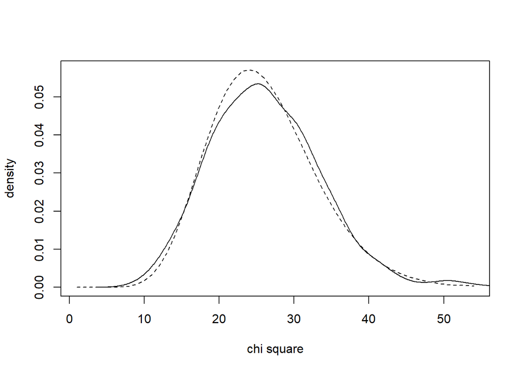

Figure 6.1: Empirical (solid) versus expected (dashed) chi-square distributions

```r
plot(dchisq(seq(max(powerCFA$simRes$fitH1[ , 'chisq'])), df = powerCFA$simRes$fitH1[1 , 'df']), type = 'l', lty = 2, xlab = 'chi square', ylab = 'density')
lines(density(powerCFA$simRes$fitH1[ , 'chisq']))
```

##### Non-normal data

By default, the data generated in a simulated power analysis are sampled from a multivariate normal distribution (by omitting `type = 'normal'` in `simOptions`). Multivariate normality is, of course, a strong assumption which is often violated in actual empirical data. Whereas the point estimates for the model parameters are still correct when the data are not normally distributed, the standard errors and - most importantly in the present context - the model test statistic will be inflated. To evaluate the extent to which power depends on the normality assumption, simulated power analyses can also be performed based on non-normal data (and optionally by also considering an alternative estimator or test-statistic).

Generating non-normal data with a given covariance structure is a tricky issue, so there are quite a number of different approaches that may be employed. A popular method is the multivariate power-constants approach by Vale and Maurelli (1983), which, however, implies a population distribution that does not depart from a multivariate normal distribution. `semPower` therefore also provides interfaces to three further approaches, each of which is associated with different classes of multivariate distributions and expects different input parameters:

- `type = 'IG'` (Foldnes & Olsson, 2016) requires provision of skewness and excess kurtosis of the marginals (i.e., for each variable) akin to the Vale-Maurelli procedure. This requires the `covsim` package.
- `type = 'mnonr'` (Qu et al., 2020) requires provision of Mardia’s multivariate skewness and kurtosis. Note that multivariate normality implies a population kurtosis of $p \cdot (p + 2)$. This requires the `mnonr` package.
- `type = 'RK'` (Ruscio & Kaczetow, 2008) requires provision of the marginal distributions (i.e., the population distribution of each variable).
- `type = 'VM'` (Vale & Maurelli, 1983) requires provision of skewness and excess kurtosis of the marginals (i.e., for each variable). Note that each kurtosis value must be $\geq \text{skew}^2 - 2$.

For instance, recurring to the example above, the following uses the IG approach (`type = 'IG'`) to generate non-normal data, where the marginal distributions of the indicators of the first factor (variables 1 - 5) have a skewness (`skewness`) of zero, but a quite strong kurtosis (`kurtosis`) between 10 - 20, whereas the indicators of the second factor (variables 6 - 9) show a minor skewness of 2 and a more moderate kurtosis between 4 - 6.

```r
set.seed(300121)
powerCFA <- semPower.powerCFA(
                              # define type of power analysis
                              type = 'post-hoc', alpha = .05, N = 300, comparison = 'restricted',
                              # define hypothesis
                              Phi = .25,
                              nullEffect = 'cor = 0',
                              # define measurement model
                              nIndicator = c(5, 4), loadM = c(.5, .6),
                              # request simulated power
                              simulatedPower = TRUE,
                              # set simulation options
                              simOptions = list(
                                type = 'IG',
                                skewness = c(0, 0, 0, 0, 0, 2, 2, 2, 2),
                                kurtosis = c(20, 15, 10, 15, 18, 5, 4, 5, 6),
                                nCores = 8
                              ))
```

The following also specifies the marginal skewness and kurtosis, but relies on the VM approach (`type = 'VM'`):

```r
set.seed(300121)
powerCFA <- semPower.powerCFA(
                              # define type of power analysis
                              type = 'post-hoc', alpha = .05, N = 300, comparison = 'restricted',
                              # define hypothesis
                              Phi = .25,
                              nullEffect = 'cor = 0',
                              # define measurement model
                              nIndicator = c(5, 4), loadM = c(.5, .6),
                              # request simulated power
                              simulatedPower = TRUE,
                              # set simulation options
                              simOptions = list(
                                type = 'VM',
                                skewness = c(1, 1, 1, 1, 1, 3, 3, 3, 3),
                                kurtosis = c(4, 4, 4, 4, 4, 15, 15, 15, 15),
                                nCores = 8
                              ))
```

Alternatively, one may specify Mardia’s multivariate skewness and kurtosis using the mnonr approach (`type = 'mnonr'`). For instance, in the following, data are sampled from a population with a multivariate skewness of 10 and a multivariate kurtosis of 200:

```r
set.seed(300121)
powerCFA <- semPower.powerCFA(
                              # define type of power analysis
                              type = 'post-hoc', alpha = .05, N = 300, comparison = 'restricted',
                              # define hypothesis
                              Phi = .25,
                              nullEffect = 'cor = 0',
                              # define measurement model
                              nIndicator = c(5, 4), loadM = c(.5, .6),
                              # request simulated power
                              simulatedPower = TRUE,
                              # set simulation options
                              simOptions = list(
                                type = 'mnonr',
                                skewness = 10,
                                kurtosis = 200,
                                nCores = 8
                              ))
```

Instead of defining the marginal skewness and kurtosis as in the IG or the VM approach, one may specify the marginal distributions themselves using the RK approach (`type = 'RK'`). This requires that the `distributions` argument is set as a list of lists, where each component must specify the population distribution for a specific variable (e.g., `rnorm`) and additional arguments (e.g, `list(mean = 0, sd = 10)`) also as a list (which may also be empty). For instance, the following defines different marginal distributions for each of the 9 indicator variables:

```r
set.seed(300121)
distributions <- list(
  list('rnorm', list(mean = 0, sd = 10)),          # normal
  list('rnorm', list()),                           # standard normal
  list('rt', list(df = 10)),                       # t
  list('runif', list()),                           # uniform (0 - 1)
  list('rbeta', list(shape1 = 1, shape2 = 2)),     # beta
  list('rexp', list(rate = 1)),                    # exponential
  list('rpois', list(lambda = 4)),                 # poisson
  list('rchisq', list(df = 4, ncp = 3)),           # chi-square
  list('rbinom', list(size = 1, prob = .5))        # binomial
)
powerCFA <- semPower.powerCFA(
                              # define type of power analysis
                              type = 'post-hoc', alpha = .05, N = 300, comparison = 'restricted',
                              # define hypothesis
                              Phi = .25,
                              nullEffect = 'cor = 0',
                              # define measurement model
                              nIndicator = c(5, 4), loadM = c(.5, .6),
                              # request simulated power
                              simulatedPower = TRUE,
                              # set simulation options
                              simOptions = list(
                                type = 'RK',
                                distributions = distributions,
                                nCores = 8
                              ))
```

One may also just define a single distribution to apply to all variables. For instance, `distributions = list('rchisq', list(df = 2))` defines the population marginal distributions for all variables to be $\chi^2$ with 2 df.

##### Missing data

By default, complete data are generated and used in simulated power analyses. Given that the presence of missing data also affects power, `semPower` also allows for generating data with missings, which are then analyzed resorting to full-information maximum likelihood.

To request missing data, the missing data mechanism, the proportion of missing data, and the variables on which missing data occur need to be defined by providing the following to `simOptions`:

- `missingVars`: vector specifying the variables containing missing data, e.g., `missingVars = c(2, 4, 6)` to have the second, fourth, and sixth variable contain missings. The order of the variables reflects the one in the particular factor model defined (see definition of the factor model).
- `missingVarProp` can be used instead of `missingVars`: the proportion of variables containing missing data.
- `missingProp`: The proportion of missingness for variables containing missing data, either a single value or a vector giving the probabilities for each variable.
- `missingMechanism`: The missing data mechanism, one of `'MCAR'` (the default), `'MAR'`, or `'NMAR'`.

For instance, recurring to the example above, the following defines a MAR missing mechanism (`missingMechanism = 'MAR'`), a proportion of missingness on the variables containing missings of .25 (`missingProp = .25`), and that variables 1, 2, 8, and 9 contain missing values (`missingVars = c(1, 2, 8, 9)`). In the present example, this means that the first and second indicator of the first factor as well as the final two indicators of the second factor contain missings.

```r
set.seed(300121)
powerCFA <- semPower.powerCFA(
                              # define type of power analysis
                              type = 'post-hoc', alpha = .05, N = 300, comparison = 'restricted',
                              # define hypothesis
                              Phi = .25,
                              nullEffect = 'cor = 0',
                              # define measurement model
                              nIndicator = c(5, 4), loadM = c(.5, .6),
                              # request simulated power
                              simulatedPower = TRUE,
                              # set simulation options
                              simOptions = list(
                                missingVars = c(1, 2, 8, 9),
                                missingProp = .25,
                                missingMechanism = 'MAR',
                                nCores = 8
                              ))
```

Alternatively, one may also specify the proportion of missing values for each variable separately. For instance, the following defines the proportion of missingness to be .1, .2, .3, and .4 (`missingProp = c(.1, .2, .3, .4)`) for variables 1, 2, 8, and 9, respectively.

```r
set.seed(300121)
powerCFA <- semPower.powerCFA(
                              # define type of power analysis
                              type = 'post-hoc', alpha = .05, N = 300, comparison = 'restricted',
                              # define hypothesis
                              Phi = .25,
                              nullEffect = 'cor = 0',
                              # define measurement model
                              nIndicator = c(5, 4), loadM = c(.5, .6),
                              # request simulated power
                              simulatedPower = TRUE,
                              # set simulation options
                              simOptions = list(
                                missingVars = c(1, 2, 8, 9),
                                missingProp = c(.1, .2, .3, .4),
                                missingMechanism = 'MAR',
                                nCores = 8
                              ))
```

Instead of defining specific variables that contain missings, it is also possible to just define the proportion of variables that contain missings (so that the specific variables containing missings are determined randomly). For instance, the following defines that 50% of the variables contain missings:

```r
set.seed(300121)
powerCFA <- semPower.powerCFA(
                              # define type of power analysis
                              type = 'post-hoc', alpha = .05, N = 300, comparison = 'restricted',
                              # define hypothesis
                              Phi = .25,
                              nullEffect = 'cor = 0',
                              # define measurement model
                              nIndicator = c(5, 4), loadM = c(.5, .6),
                              # request simulated power
                              simulatedPower = TRUE,
                              # set simulation options
                              simOptions = list(
                                missingVarProp = .50,
                                missingProp = .25,
                                missingMechanism = 'MAR',
                                nCores = 8
                              ))
```

##### Changing the estimator and test-statistic

By default, simulated power analyses are performed using Maximum-Likelihood estimation with the standard LR test-statistic. When non-normal data are incorporated in the simulation process, the standard test-statistic will be positively biased and thus may incur inflated power estimates, so it is reasonable to employ corrected test-statistics. The test-statistic and the estimator can be changed by providing a list to the `lavOptions` argument, which is passed to `lavaan` and thus conforms to the standard `lavaan` conventions. For example:

- `list(estimator = 'mlm')`: requests ML estimation with the Satorra-Bentler scaled test-statistic
- `list(estimator = 'mlr')`: requests ML estimation with a corrected test-statistic that is asymptotically equivalent to the Yuan-Bentler statistic
- `list(estimator = 'wls')`: requests WLS estimation
- `list(estimator = 'wlsmv')`: requests diagonal WLS estimation with a robust test-statistic

See the `lavaan` manual for all available estimators and test-statistics.

For instance, the following generates non-normal data with missings (see the preceeding chapters) and employs ML estimation with a test-statistic asymptotically equivalent to the Yuan-Bentler statistic (`lavOptions = list(estimator = 'mlr')`).

```r
set.seed(300121)
powerCFA <- semPower.powerCFA(
                              # define type of power analysis
                              type = 'post-hoc', alpha = .05, N = 300, comparison = 'restricted',
                              # define hypothesis
                              Phi = .25,
                              nullEffect = 'cor = 0',
                              # define measurement model
                              nIndicator = c(5, 4), loadM = c(.5, .6),
                              # request simulated power
                              simulatedPower = TRUE,
                              # set simulation options
                              simOptions = list(
                                type = 'mnonr',
                                skewness = 10,
                                kurtosis = 200,
                                missingVars = c(1, 2, 8, 9),
                                missingProp = c(.1, .2, .3, .4),
                                missingMechanism = 'MAR'
                              ),
                              lavOptions = list(estimator = 'mlr'))
```

## 6.5 Power analyses based on covariance matrices

All model-free power analyses provided in `semPower` also accept covariance matrices as input and then determine the associated effect through the supplied covariance matrices. This offers a very high degree of flexibility, but obviously requires a specification of proper covariance matrices. In this section, various options to obtain these matrices are illustrated in detail, ordered by most to least cumbersome.

##### The full way

One way is to employ some other SEM software to generate the population and the model-implied covariance matrix (note that a proper definition of the latter usually requires fitting the model to the population data). For illustration, let’s consider how this could be done using `lavaan`.

```r
library(lavaan)

# define (true) population model
modelPop <- '
f1 =~ .8*x1 + .7*x2 + .6*x3
f2 =~ .7*x4 + .6*x5 + .5*x6
f1 ~~ 1*f1
f2 ~~ 1*f2
f1 ~~ 0.5*f2
x1 ~~ .36*x1
x2 ~~ .51*x2
x3 ~~ .64*x3
x4 ~~ .51*x4
x5 ~~ .64*x5
x6 ~~ .75*x6
'
# define (wrong) H0 model
modelH0<- '
f1 =~ x1 + x2 + x3
f2 =~ x4 + x5 + x6
f1 ~~ 0*f2
'
```

After loading the `lavaan` package, two lavaan model strings are defined. The first model string (`modelPop`) is used to define the population covariance matrix, so all model parameters are defined (at least implicitly, consult the lavaan documentation for defaults). Here, a model is defined comprising two latent factors (each with variance of 1), that are correlated by .5. Each latent factor is measured through three observed indicators (x1 to x6) with (standardized) loadings ranging from .5 to .8. The second model string (`modelH0`) is used to define the hypothesized (wrong) H0 model. To obtain the model-implied covariance matrix, one needs to fit this model to the population data; so this is basically an ordinary CFA model string with many free parameters. Note that this model constrains the correlation between the two latent factors to zero. When fitting this model to the population data defined previously, the model is thus wrong, since the correlation between these factors in the population was defined to be .50.

Having defined the model strings, one proceeds by actually obtaining the relevant covariance matrices.

```r
# get population covariance matrix; equivalent to a perfectly fitting model
covPop <- fitted(sem(modelPop))$cov

# get covariance matrix as implied by H0 model; note the nobs are arbitrary
fitH0 <- sem(modelH0, sample.cov = covPop,
              sample.nobs = 250, sample.cov.rescale = FALSE,
              likelihood = 'wishart')
df <- fitH0@test[[1]]$df
covH0 <- fitted(fitH0)$cov
```

`covPop` is now the covariance matrix in the population ($\Sigma$). To obtain the model-implied covariance matrix ($\hat{\Sigma}$), one needs to fit our hypothesized, wrong, H0 model (`modelH0`) to the population data (`covPop`). The model-implied covariance matrix can then be obtained by calling `covH0 <- fitted(fitH0)$cov`.

```r
ph <- semPower.postHoc(SigmaHat = covH0, Sigma = covPop, alpha = .05, N = 250, df = df)
summary(ph)
```

The output (which is omitted here) indicates that fitting the hypothesized model to the population data is associated with a discrepancy of $F_0$ = 0.133 (or RMSEA = .121 or SRMR = .140 or …) and that the power to reject the H0 model is very high, 1 - beta = .993.

It is instructive to compare the expected $\chi^2$ (computed via the obtained $F_0$) with the $\chi^2$ model test statistics as reported by `lavaan` when fitting the H0 model using the same number of observations as requested in the power analysis:

```r
fitmeasures(fitH0, 'chisq')
ph$fmin * (ph$N-1)
```

##### Using semPower.powerLav

The process illustrated above can be simplified by calling `semPower.powerLav`. In essence, all what is needed now are the population model string (`modelPop`) and the H0 model string (`modelH0`). This leads to:

```r
ph <- semPower.powerLav(type = 'post-hoc',
                        modelPop = modelPop, modelH0 = modelH0,
                        alpha = .05, N = 250)
summary(ph)
```

which - of course - yields the same results.

##### Using semPower.powerLav in conjunction with semPower.genSigma

Instead of defining the population covariance matrix through a `lavaan` model string, It is often easier to obtain the population covariance matrix through the `semPower.genSigma` function, because this takes care for many intricacies such as the correct definition of the residual variances. In the scenario above, the following leads to the same results:

```r
generated <- semPower.genSigma(Phi = .50,
                               loadings = list(
                                 c(.8, .7, .6),
                                 c(.7, .6, .5)))
ph <- semPower.powerLav(type = 'post-hoc',
                        Sigma = generated$Sigma, modelH0 = modelH0,
                        alpha = .05, N = 250)
summary(ph)
```

##### Using semPower.powerCFA

As the scenario above involves a model and a hypothesis that can be immediately handled by the `semPower.powerCFA` convenience function, actually none of the above is required and could be achieved by a simple call to `semPower.powerCFA`:

```r
ph <- semPower.powerCFA(type = 'post-hoc',
                        comparison = 'saturated',
                        Phi = .5,
                        loadings = list(
                          c(.8, .7, .6),
                          c(.7, .6, .5)),
                        alpha = .05, N = 250)
summary(ph)
```

In the background, `semPower.powerCFA` performs all the necessary steps outlined above, so the results will - of course - be the same. Note the argument `comparison = 'saturated'` was set so to obtain the power to reject the H0 model when compared against the saturated model, which was also done in all examples above.

## 6.6 Generate a covariance matrix and lavaan model strings

Internally, all convenience functions performing a model-based power analysis generate a population variance-covariance matrix and, along with proper model strings, plug it into the `semPower.powerLav` function, which in turn transforms a model-based power analysis into a model-free power analysis providing population and model-implied covariance matrices as input.

`semPower.genSigma` expects model matrices as input parameters, so different matrices need to be provided depending on whether a CFA or a SEM model is specified.

##### CFA model

In the CFA model, the model-implied variance-covariance matrix is given by
$$\Sigma = \Lambda \Phi \Lambda' + \Theta$$
where $\Lambda$ is the $p \times m$ loading matrix, $\Phi$ is the $m \times m$ variance-covariance matrix of the $m$ factors, and $\Theta$ is the residual variance-covariance matrix of the observed variables. The means are
$$\mu = \tau + \Lambda \alpha$$
with the $p$ indicator intercepts $\tau$ and the $m$ factor means $\alpha$.

Thus, to generate a CFA model-implied covariance matrix, `Phi` and `Lambda` (or respective shortcuts) need to be provided. For instance, the following generates the implied covariance matrix for a three-factor model with factor correlations as defined in `Phi` and the loading matrix as defined in `Lambda`:

```r
  Phi <- matrix(c(
    c(1.0, 0.5, 0.1),
    c(0.5, 1.0, 0.2),
    c(0.1, 0.2, 1.0)
  ), byrow = T, ncol=3)
  Lambda <- matrix(c(
    c(0.4, 0.0, 0.0),
    c(0.7, 0.0, 0.0),
    c(0.8, 0.0, 0.0),
    c(0.0, 0.6, 0.0),
    c(0.0, 0.7, 0.0),
    c(0.0, 0.4, 0.0),
    c(0.0, 0.0, 0.8),
    c(0.0, 0.0, 0.7),
    c(0.0, 0.0, 0.8)
  ), byrow = T, ncol = 3)

  gen <- semPower.genSigma(Phi = Phi, Lambda = Lambda)
```

`semPower.genSigma` returns a list comprising all model matrices (in the example above, `Lambda`, `Phi`, and the variance-covariance matrix of the manifest residuals, `Theta`) and the model-implied variance-covariance matrix `Sigma`. In addition, various `lavaan` model strings are also returned:

- `modelPop` model string defining a population model corresponding to the model matrices.
- `modelTrue` analysis model (yielding a perfect model fit) .
- `modelTrueCFA` only for SEM models: a pure CFA analysis model string omitting any regression relationships between the latent factors and rather allowing all latent factors to be correlated.

Thus, plugging the generated variance-covariance matrix and the generated true model string into `lavaan` yields estimates that mirror the defined population matrices:

```r
library(lavaan)
summary(sem(gen$modelTrue,
            sample.cov = gen$Sigma,
            sample.nobs = 1000,
            sample.cov.rescale = FALSE))
```

Instead of providing the complete loading matrix as an argument for `Lambda`, `semPower.genSigma` also understands the shortcuts as described in detail here.

If any of the arguments is provided as a list (e.g., `Lambda = list(Lambda1, Lambda2)`), multiple implied covariance matrices are returned. This is particularly useful for multigroup analyses, where the covariance matrices differ across groups. For instance, the following defines the same measurement model for two groups (by providing a single argument to `Lambda`), but defines different factor correlations for the groups, so that two model-implied covariance matrices are returned:

```r
  Phi1 <- matrix(c(
     c(1.0, 0.5, 0.1),
     c(0.5, 1.0, 0.2),
     c(0.1, 0.2, 1.0)
  ), byrow = T, ncol=3)
  Phi2 <- matrix(c(
     c(1.0, 0.6, 0.2),
     c(0.6, 1.0, 0.3),
     c(0.2, 0.3, 1.0)
  ), byrow = T, ncol=3)

  gen <- semPower.genSigma(Phi = list(Phi1, Phi2), Lambda = Lambda)
```

##### SEM model

If the model-implied covariance matrix is rather to be determined from a structural equation model (instead a CFA model), `semPower.genSigma` expects as arguments `Beta`, `Psi`, and `Lambda` (or respective shortcuts). In the structural equation model, the model-implied covariance matrix is given by

$$\Sigma = \Lambda (\mathbf{I} - \mathbf{B})^{-1} \Psi [(\mathbf{I} - \mathbf{B})^{-1}]' \Lambda' + \Theta$$
where $\mathbf{B}$ is the $m \times m$ matrix containing the regression slopes and $\Psi$ is the (residual) variance-covariance matrix of the $m$ factors. The means are
$$\mu = \tau + \Lambda (\mathbf{I} - \mathbf{B})^{-1} \alpha$$

The structural part of the model is primarily defined through Beta ($\mathbf{B}$). As an example, suppose there are four factors ($X_1$, $X_2$, $X_3$, $X_4$), and Beta is defined as follows:
$$\begin{array}{lrrr}
& X_1 & X_2 & X_3 & X_4\\
X_1 & 0.0 & 0.0 & 0.0 & 0.0 \\
X_2 & 0.0 & 0.0 & 0.0 & 0.0 \\
X_3 & 0.2 & 0.3 & 0.0 & 0.0 \\
X_4 & 0.3 & 0.5 & 0.0 & 0.0 \\
\end{array}$$
Each row specifies how a particular factor is predicted by the available factors, so the above implies the following regression relations:

$$X_1 = 0.0 \cdot X_1 + 0.0 \cdot X_2 + 0.0 \cdot X_3 + 0.0 \cdot X_4 \\
X_2 = 0.0 \cdot X_1 + 0.0 \cdot X_2 + 0.0 \cdot X_3 + 0.0 \cdot X_4 \\
X_3 = 0.2 \cdot X_1 + 0.3 \cdot X_2 + 0.0 \cdot X_3 + 0.0 \cdot X_4 \\
X_4 = 0.3 \cdot X_1 + 0.5 \cdot X_2 + 0.0 \cdot X_3 + 0.0 \cdot X_4$$

which simplifies to

$$X_3 = 0.2 \cdot X_1 + 0.3 \cdot X_2 \\
X_4 = 0.3 \cdot X_1 + 0.5 \cdot X_2$$

Psi ($\Psi$) defines the (residual-)variances and whether there are (residual-)covariances between the factors. Suppose that $\Psi$ is
$$\begin{array}{lrrr}
& X_1 & X_2 & X_3 & X_4\\
X_1 & 1.0 & 0.3 & 0.0 & 0.0 \\
X_2 & 0.3 & 1.0 & 0.0 & 0.0 \\
X_3 & 0.0 & 0.0 & 1.0 & 0.2 \\
X_4 & 0.0 & 0.0 & 0.2 & 1.0 \\
\end{array}$$

which implies that the variances of $X_1$ and $X_2$ are 1, and that the residual variances of $X_3$ and $X_4$ are also 1. Further, the covariance between $X_1$ and $X_2$ is .3 (which is also a correlation, because both variances are 1) and a residual covariance between $X_3$ and $X_4$ of .2 (which is *not* a correlation, because the variances of $X_3$ and $X_4$ also depend on Beta).

The scenario just described can be achieved by defining `Beta` and `Psi` accordingly and plugging these as input to `semPower.genSigma`:

```r
Beta <- matrix(c(
  c(.00, .00, .00, .00),
  c(.00, .00, .00, .00),
  c(.20, .30, .00, .00),
  c(.30, .50, .00, .00)
), byrow = TRUE, ncol = 4)
Psi <- matrix(c(
  c(1, .30, .00, .00),
  c(.30, 1, .00, .00),
  c(.00, .00, 1, .20),
  c(.00, .00, .20, 1)
), byrow = TRUE, ncol = 4)

gen <- semPower.genSigma(Beta = Beta, Psi = Psi, Lambda = diag(ncol(Beta)))
```

In the example above, a model with manifest variables only is defined by setting `Lambda = diag(ncol(Beta))`. If providing a loading matrix or any of the shortcuts instead, a genuine SEM model (including latent factors) is defined, as in the following example:

```r
gen <- semPower.genSigma(Beta = Beta, Psi = Psi,
                         loadM = .5, nIndicator = c(5, 4, 5, 6))
```

`semPower.genSigma` again returns a list comprising all model matrices (here: `Lambda`, `Beta`, `Psi`, and the variance-covariance matrix of the manifest residuals, `Theta`) and the model-implied variance-covariance matrix `Sigma`. In addition, the same `lavaan` model strings as in the CFA case are returned. Thus, again, plugging the generated variance-covariance matrix and the generated true model string into `lavaan` yields estimates that mirror the defined population matrices:

```r
summary(sem(gen$modelTrue,
            sample.cov = gen$Sigma,
            sample.nobs = 1000,
            sample.cov.rescale = FALSE))
```

In the SEM case, `semPower.genSigma` also returns a pure CFA model that just estimates the factors and allows these factors to correlate, but discards any regression relationships between the factors:

```r
summary(sem(gen$modelTrueCFA,
            sample.cov = gen$Sigma,
            sample.nobs = 1000,
            sample.cov.rescale = FALSE))
```

# References

- Browne, M. W., & Cudeck, R. (1992). Alternative ways of assessing model fit. *Sociological Methods & Research, 21*, 230–258.https://doi.org/10.1177/0049124192021002005
- Foldnes, N. & Olsson, U. H. (2016) A Simple Simulation Technique for Nonnormal Data with Prespecified Skewness, Kurtosis, and Covariance Matrix. *Multivariate Behavioral Research, 51*, 207-219. https://doi.org/10.1080/00273171.2015.1133274
- Jöreskog, K. G., & Sörbom, D. (1984). *LISREL VI user’s guide* (3rd ed.). Scientific Software.
- Lin, J., & Bentler, P. M. (2012). A third moment adjusted test statistic for small sample factor analysis. *Multivariate Behavioral Research, 47(3),* 448-462. https://doi.org/10.1080/00273171.2012.673948
- McDonald, R. P. (1989). An index of goodness-of-fit based on noncentrality. *Journal of Classification, 6*, 97–103. https://doi.org/10.1007/BF01908590
- MacCallum, R. C., Browne, M. W., & Sugawara, H. M. (1996). Power analysis and determination of sample size for covariance structure modeling. *Psychological Methods, 1*, 130–149. https://doi.org/10.1037/1082-989X.1.2.130
- Moshagen, M., & Erdfelder, E. (2016). A new strategy for testing structural equation models. *Structural Equation Modeling, 23*, 54–60. https://doi.org/10.1080/10705511.2014.950896
- Qu, W., Liu, H., & Zhang, Z. (2020). A method of generating multivariate non-normal random numbers with desired multivariate skewness and kurtosis. *Behavior Research Methods, 52*, 939-946. [https://doi.org/10.3758/s13428-019-01291-5] (https://doi.org/10.3758/s13428-019-01291-5)
- Rosseel, Y. (2012). lavaan: An R package for structural equation modeling. *Journal of Statistical Software, 48,* 1-36. https://doi.org/10.18637/jss.v048.i02
- Ruscio, J., & Kaczetow, W. (2008). Simulating multivariate nonnormal data using an iterative algorithm. *Multivariate Behavioral Research, 43*, 355-381. https://doi.org/10.1080/00273170802285693
- Steiger, J. H. (1990). Structural model evaluation and modification: An interval estimation approach. *Multivariate Behavioral Research, 25*, 173–180. https://doi.org/10.1207/s15327906mbr2502_4
- Steiger, J. H., & Lind, J. C. (1980). *Statistically based tests for the number of common factors*. Presented at the Annual meeting of the Psychometric Society, Iowa City.
- Stoel, R. D., Garre, F. G., Dolan, C., & Van Den Wittenboer, G. (2006). On the likelihood ratio test in structural equation modeling when parameters are subject to boundary constraints. *Psychological Methods, 11*, 439-455. https://doi.org/10.1037/1082-989X.11.4.439
- Tofighi, D., & Kelley, K. (2020). Improved inference in mediation analysis: Introducing the model-based constrained optimization procedure. *Psychological Methods, 25*, 496–515. https://doi.org/10.1037/met0000259
- Vale, C. D., & Maurelli, V. A. (1983). Simulating Multivariate Nonnormal Distributions. *Psychometrika, 48*, 465–471. https://doi.org/10.1007/bf02293687
- Yuan, K.-H., & Maxwell, S. (2005). On the post hoc power in testing mean differences. *Journal of Educational and Behavioral Statistics, 30*, 141–167. https://doi.org/10.3102/10769986030002141
[^1]: For instance, when using a constant value for the RMSEA as an effect size metric, power decreases with increasing df, because the implied $F_0$ decreases.
[^2]: A third type implements order constraints on parameters, but this is associated with certain intricacies concerning the limiting distributions and not covered by `semPower`.
[^3]: This may change once `lavaan` supports an optimizer that better copes with non-linear constraints, such as NPSOL or SLSQP.
[^4]: The estimated power in this particular example is only approximate, because the H0 model involves a parameter constraint on the boundary of the parameter space (i.e, constraining the factor correlation to 1), so that the correct limiting distribution is a mixture of non-central $\chi^2$ distributions (see Stoel et al., 2006). In effect, power is (slightly) underestimated.
[^5]: Note that factor (residual) variances can be omitted, because each factor needs to be assigned a scale, so one free parameter is lost for each factor anyway. Concerning the number of free parameters, it does not matter whether factors are identified by fixing their variance or by fixing one loading.
[^6]: Simulated power is not supported for compromise power analysis, because this required an unfeasible large number of replications to yield reliable results.